# CMSC320 Final Project

Rafa Mondal | 117134698  
Zachary Smith | 117212068

# Data Collection

To aquire this data, we looked to the Materia Collective, a record label that puts out exclusively videogame soundtracks and covers of videogame soundtrakcs. Their bandcamp site (https://bandcamp.materiacollective.com/) contains a table with links to bancdcamp pages for all of the albums the label has published.With some html scraping we can extract some information about the albums.

```python
import requests
import pandas as pd
from bs4 import BeautifulSoup
import re
import numpy as np
from pandas.core.arrays.datetimelike import TimelikeOps
```

```python
# Setting up accumulator dataframes
master_track_df = pd.DataFrame()
master_album_df = pd.DataFrame()
```

```python
# Get a list of links to all the album bandcamp sites
html = requests.get('https://bandcamp.materiacollective.com/')
data = BeautifulSoup(html.text, 'html.parser')

urls = []

tiles1 = data.findAll('li', {'class': 'featured-item'})
tiles2 = data.findAll('li', {'class': 'music-grid-item square first-four '})
tiles3 = data.findAll('li', {'class': 'music-grid-item square '})

for square in tiles1 + tiles2 + tiles3:
    square = str(square)
    square = square[square.index('href="') + 6:]
    square = square[:square.index('"')]
    if square.index('/album/') == 0:
        square = 'https://bandcamp.materiacollective.com' + square
    urls.append(square)
urls
```

```
['https://ericbuchholz.bandcamp.com/album/a-merry-hyrule-christmas?label=3683409508&amp;tab=music',
 'https://familyjules7x.bandcamp.com/album/jack-of-hearts?label=3683409508&amp;tab=music',
 'https://familyjules7x.bandcamp.com/album/king-of-hearts?label=3683409508&amp;tab=music',
 'https://familyjules7x.bandcamp.com/album/queen-of-hearts?label=3683409508&amp;tab=music',
 'https://valterabreu.bandcamp.com/album/nightslink-original-game-soundtrack?label=3683409508&amp;tab=music',
 'https://ryanike.bandcamp.com/album/shadows-over-loathing-original-game-soundtrack?label=3683409508&amp;tab=music',
 'https://waynestrange.bandcamp.com/album/pursuit-a-great-turnabout-from-the-great-ace-attorney?label=3683409508&amp;tab=music',
 'https://videogamemusicbox.bandcamp.com/album/music-box-classics-kingdom-hearts-ii?label=3683409508&amp;tab=music',
 'https://videogamemusicbox.bandcamp.com/album/music-box-classics-mega-man-2?label=3683409508&amp;tab=music',
 'https://videogamemusicbox.bandcamp.com/album/music-box-classics-final-fantasy-x?label=3683409508&amp;tab=music',
 'https://polyarcgames.bandcamp.com/album/moss-book-ii-original-game-soundtrack?label=3683409508&amp;tab=music',
 'https://videogamemusicbox.bandcamp.com/album/music-box-classics-nier-automata?label=3683409508&amp;tab=music',
 'https://music.rozen.audio/album/battle-for-spira-from-final-fantasy-x?label=3683409508&amp;tab=music',
 'https://music.rozen.audio/album/fated-children-from-final-fantasy-viii?label=3683409508&amp;tab=music',
 'https://videogamemusicbox.bandcamp.com/album/music-box-classics-ragnarok-online?label=3683409508&amp;tab=music',
 'https://music.rozen.audio/album/where-i-belong-from-final-fantasy-viii?label=3683409508&amp;tab=music',
 'https://music.rozen.audio/album/wizpig-from-diddy-kong-racing?label=3683409508&amp;tab=music',
 'https://videogamemusicbox.bandcamp.com/album/music-box-classics-super-mario-galaxy?label=3683409508&amp;tab=music',
 'https://videogamemusicbox.bandcamp.com/album/music-box-classics-plants-vs-zombies?label=3683409508&amp;tab=music',
 'https://vgoonline.bandcamp.com/album/live-in-japan?label=3683409508&amp;tab=music',
 'https://videogamemusicbox.bandcamp.com/album/music-box-classics-xenogears?label=3683409508&amp;tab=music',
 'https://videogamemusicbox.bandcamp.com/album/music-box-classics-chrono-cross?label=3683409508&amp;tab=music',
 'https://videogamemusicbox.bandcamp.com/album/music-box-classics-hollow-knight?label=3683409508&amp;tab=music',
 'https://videogamemusicbox.bandcamp.com/album/music-box-classics-the-witcher-3-wild-hunt?label=3683409508&amp;tab=music',
 'https://videogamemusicbox.bandcamp.com/album/music-box-classics-the-legend-of-zelda-breath-of-the-wild?label=3683409508&amp;tab=music',
 'https://videogamemusicbox.bandcamp.com/album/music-box-classics-deltarune-vol-3?label=3683409508&amp;tab=music',
 'https://stringplayergamer.bandcamp.com/album/acoustica-the-legend-of-zelda?label=3683409508&amp;tab=music',
 'https://joshbarronstudios.bandcamp.com/album/kaleidoscope-sakimoto-and-hamauzu-works?label=3683409508&amp;tab=music',
 'https://familyjules7x.bandcamp.com/album/knock-you-down-from-deltarune-chapter-2?label=3683409508&amp;tab=music',
 'https://familyjules7x.bandcamp.com/album/a-cybers-world-from-deltarune-chapter-2-metal-version?label=3683409508&amp;tab=music',
 'https://akuparagames.bandcamp.com/album/grime-ambiances-original-game-soundtrack?label=3683409508&amp;tab=music',
 'https://familyjules7x.bandcamp.com/album/big-shot-from-deltarune-chapter-2-metal-version?label=3683409508&amp;tab=music',
 'https://vgoonline.bandcamp.com/album/live-in-brazil?label=3683409508&amp;tab=music',
 'https://familyjules7x.bandcamp.com/album/attack-of-the-killer-queen-from-deltarune-chapter-2?label=3683409508&amp;tab=music',
 'https://music.rozen.audio/album/nier-become-as-gods?label=3683409508&amp;tab=music',
 'https://bandcamp.materiacollective.com/album/gris-piano-collections',
 'https://akuparagames.bandcamp.com/album/behind-the-frame-the-finest-scenery-original-game-soundtrack?label=3683409508&amp;tab=music',
 'https://akuparagames.bandcamp.com/album/grime-original-game-soundtrack?label=3683409508&amp;tab=music',
 'https://roninopf.bandcamp.com/album/noises-from-shibuya?label=3683409508&amp;tab=music',
 'https://luciholland.bandcamp.com/album/murderous-pursuits-original-game-soundtrack?label=3683409508&amp;tab=music',
```

[output cut: 240 more lines]

```
 'https://theophany-rmx.bandcamp.com/album/times-end-ii-majoras-mask-remixed?label=3683409508&amp;tab=music',
 'https://multiplayercharity.bandcamp.com/album/multiplayer-iii-wave?label=3683409508&amp;tab=music',
 'https://insaneintherainmusic.bandcamp.com/album/live-at-grillbys?label=3683409508&amp;tab=music',
 'https://music.rozen.audio/album/dear-to-the-heart-from-final-fantasy-vii?label=3683409508&amp;tab=music',
 'https://multiplayercharity.bandcamp.com/album/multiplayer-ii-co-op?label=3683409508&amp;tab=music',
 'https://joshbarronstudios.bandcamp.com/album/the-ethereal-string-project?label=3683409508&amp;tab=music',
 'https://projectdestati.bandcamp.com/album/project-destati-light?label=3683409508&amp;tab=music',
 'https://multiplayercharity.bandcamp.com/album/multiplayer-a-tribute-to-video-games?label=3683409508&amp;tab=music',
 'https://chasebethea.bandcamp.com/album/deity-quest-original-soundtrack?label=3683409508&amp;tab=music',
 'https://vgoonline.bandcamp.com/album/live-at-symphony-hall?label=3683409508&amp;tab=music',
 'https://projectdestati.bandcamp.com/album/project-destati-awakening?label=3683409508&amp;tab=music',
 'https://theophany-rmx.bandcamp.com/album/times-end-majoras-mask-remixed?label=3683409508&amp;tab=music',
 'https://braxtonburks.bandcamp.com/album/kanto-symphony-music-from-pok-mon-red-and-blue?label=3683409508&amp;tab=music',
 'https://alexanderbrandon.bandcamp.com/album/tyrian-original-soundtrack?label=3683409508&amp;tab=music',
 'https://souleyedigitalmusic.bandcamp.com/album/pppppp-the-vvvvvv-soundtrack?label=3683409508&amp;tab=music']
```

That's a lot of albums! Each website has about the same format. There are some weird quirks about some pages, like full rows in the song list for lyrics, and links to music videos, but we can account for those cases.

```python
for url in urls:
    html = requests.get(url)
    data = BeautifulSoup(html.text, 'html.parser')

    # Getting album title and artist
    album_title = data.find('h2', {'class': 'trackTitle'})
    artist = str(album_title.next_sibling.next_sibling.find('a'))
    artist = artist[artist.index('>') + 1:-4]
    album_title = str(album_title)[36:-27]

    # Getting prices for each of the formats
    formats = ['Digital Album', 'Compact Disc', 'Record/Vinyl']
    prices = [np.nan] * len(formats)
    for i in range(0,len(formats)):
        price = data.find(text=re.compile('Buy ' + formats[i]))
        # If an element with the right format is found, extract the price and add to array
        # In the case of None, there is no option to buy this way, only either CD or Vinyl
        if price != None:
            prices[i] = str(price.next_element.next_element.find(text=re.compile('\$')))[1:]

    # Getting a list of all of the tags for the album
    tags = []
    for tag_data in data.findAll('a', {'class': 'tag'}):
        tag_data = str(tag_data)
        tags.append(tag_data[tag_data.index('>') + 1:-4])

    # Get the album release date
    from itertools import islice
    release = str(next(islice(data.find('div',{'class': 'tralbumData tralbum-credits'}).children, 0, None)))
    release = pd.to_datetime(release[39:-26])

    # Clean the HTML table, because some include lyrics rows
    tracks_table = data.find('table', {'class': 'track_list track_table'})
    table_clean = '<table class="track_list track_table" id="track_table">\n'
    tracks_table = data.find('table', {'class': 'track_list track_table'})
    for row in tracks_table.findAll('tr', {'class': 'track_row_view linked'}):
        table_clean = table_clean + str(row)
    table_clean = table_clean + '</table>'
    track_df = pd.read_html(table_clean)[0]

    # Clean the resulting pandas dataframe
    track_df.rename(columns={1: "Number in Album", 2: "Title"}, inplace=True)
    track_df.drop(columns=[0,3,4], axis=1, inplace=True)
    track_df["Number in Album"] = track_df["Number in Album"].astype(float).astype(int)
    track_df["Title"] = track_df["Title"].apply(lambda x: x.rstrip('abcdefghijklmnopqrstuvwxyz '))
    track_df["Duration"] = track_df["Title"].apply(lambda x: x[-5:])
    track_df["Duration"] = pd.to_timedelta('00:' + track_df["Duration"])
    track_df["Title"] = track_df["Title"].apply(lambda x: x[:-7])
    track_df['Album Title'] = album_title

    # Get cummulative values from this section of the track dataframe
    album_duration = track_df['Duration'].sum()
    number_of_tracks = track_df['Number in Album'].max()

    # Construct the new row for the album dataframe
    album_data = [[album_title, artist, release, number_of_tracks, album_duration, prices[0], prices[1], prices[2], tags]]
    album_cols = ['Album Title', 'Artist', 'Release Date', 'Number of Tracks', 'Album Duration', 'Digital Price', 'CD Price', 'Vinyl Price', 'Tags']
    album_df = pd.DataFrame(album_data, columns=album_cols)

    # Concatenate to accumulators
    master_track_df = pd.concat([master_track_df, track_df])
    master_album_df = pd.concat([master_album_df, album_df])
```

```python
master_album_df['Digital Price'] = master_album_df['Digital Price'].apply(lambda x: np.nan if x == 'one' else x)
#master_track_df.to_csv('bandcamp_track_df.csv',index=False)  Commented out so we don't accidentally overwrite the data we originally scraped.
#master_album_df.to_csv('bandcamp_album_df.csv',index=False)
```

So now we have data from bandcamp on the Materia Collective. Thing is, it's not the greatest. The artists have no clear rule for how they are listed. Most of the time, there is one artist and it's listed in the artist place on the webpage only. Unfortunately, many times there are many artists. For some albums, this means the album artist is 'Various Artists' and each track title is formatted [Artist] - [Track Title] (which is awful because some normal track titles already have a hyphen). For other albums, the artist for the album is listed as 'artist1, artist2' or 'artist1 and artist2' or 'artist1&artist2'. It's a bit of a nightmare. Finally, the most interesting feature of this particular set of data isn't in this set of data: popularity.

So... now that we've put this much work into scraping Bandcamp, let's use the Spotify API.

```python
# Spotify stuff
!pip install Spotipy
import os
os.environ['SPOTIPY_CLIENT_ID'] = '[MY CLIENT ID]'
os.environ['SPOTIPY_CLIENT_SECRET'] = '[MY CLIENT SECRET]'
import spotipy
```

```python
from spotipy.oauth2 import SpotifyClientCredentials
spotify = spotipy.Spotify(auth_manager=SpotifyClientCredentials())
```

```python
# Load our data back in and do some additional cleaning--some unprintable characters
track_df = pd.read_csv('bandcamp_track_df.csv')
track_df['Title'] = track_df['Title'].apply(lambda x: x[x.index(' - ') + 3:] if ' - ' in x else x)
track_df['Title'] = track_df['Title'].apply(lambda x: x.replace('\u200b',''))
track_df['Album Title'] = track_df['Album Title'].apply(lambda x: x.replace('\u200b',''))
album_df = pd.read_csv('bandcamp_album_df.csv')
album_df['Album Title'] = album_df['Album Title'].apply(lambda x: x.replace('\u200b',''))
```

Okay, so the plan is to sort the albums into two groups: those that the Spotify search algorithm will likely easily find just from the album title, and those that it will probably also need a song title to find. We make this distinction by the number of spaces that appear in the album title, which we make a new dummy column in the album dataframe.

Part 1 - albums with short titles:

```python
# Make list of tuples (Album Title, query that we'll give to Spotify)
album_df['spaces'] = album_df['Album Title'].apply(lambda x: x.count(' '))
lessthan3 = album_df[album_df['spaces'] < 3]
searches = lessthan3['Album Title'].apply(lambda album_title: (album_title, track_df[track_df['Album Title'] == album_title]['Title'].iloc[0] + ' ' + album_title))
searches
```

```
16     (Live in Japan, The World Warrior (from "Stree...
29     (Live in Brazil, Prelude (from "Final Fantasy"...
32     (Gris Piano Collections, Gris, Pt. 1 Gris Pian...
35     (Noises from Shibuya, Make or Break (Shatter t...
42     (Unplugged, Bros on the Road (from "FINAL FANT...
45     (Undertale LIVE, Once Upon a Time Undertale LIVE)
48     (Crest of Flames, Three Houses Main Theme Cres...
55           (Fallen Hero, Once Upon a Time Fallen Hero)
61     (Towards the Sun, My Burden is Light Towards t...
67          (Fuzzy Pickles, Bein' Friends Fuzzy Pickles)
74          (The Keyblade War, Destati The Keyblade War)
75     (Strings of Fate, Last Surprise (Instrumental ...
78                         (Reignite, Reignite Reignite)
84     (Metroid Piano, Prologue (from "Super Metroid"...
85     (Bits and Bytes, Main Theme (Chrono Trigger) B...
```

[output cut: 42 more lines]

```python
song_query_results = []
for i, (album_title, search_q) in searches.iteritems():
    #result = spotify.search(q=search_q, type='track') Commented out so we don't accidentally query Spotify more
    song_query_results.append((i,result))
```

```python
spotify_albums_df_pt1 = pd.DataFrame()
j = 0
for (i, result) in song_query_results:
    album_info = result['tracks']['items'][0]['album']
    album_name = album_info['name']
    album_id = album_info['id']
    album_release = album_info['release_date']
    album_no_tracks = album_info['total_tracks']
    album_type = album_info['album_type']
    album_cover_url = album_info['images'][0]['url']
    artists = []
    for artist in album_info['artists']:
        artists.append(artist['name'])
    row = [[i, album_id, album_name, artists, album_type, album_no_tracks, album_release, album_cover_url, 'track', j]]
    j = j + 1
    #print(row)
    labels = ['Index', 'Album ID', 'Album Title', 'Artists', 'Album Type', 'Number of Tracks', 'Spotify Release Date', 'Image URL', 'Search Type', 'Search Index']
    df_row = pd.DataFrame(row, columns=labels)

    spotify_albums_df_pt1 = pd.concat([spotify_albums_df_pt1, df_row])
spotify_albums_df_pt1
```

|  | Index | Album ID | Album Title | Artists | Album Type | Number of Tracks | Spotify Release Date | Image URL | Search Type | Search Index |
| --- | --- | --- | --- | --- | --- | --- | --- | --- | --- | --- |
| 0 | 16 | 4Wmo27x9XdijBgMwWmzSx6 | Live in Japan | [Video Game Orchestra] | album | 13 | 2022-05-20 | https://i.scdn.co/image/ab67616d0000b273b25db6... | track | 0 |
| 0 | 29 | 6L12EEAmIaMV5BG2OGYPbs | Live in Brazil | [Video Game Orchestra] | album | 14 | 2021-10-01 | https://i.scdn.co/image/ab67616d0000b273bc93b9... | track | 1 |
| 0 | 32 | 6sWfRQuDQuVw80DMd5xRTE | Gris Piano Collections | [Berlinist, David Peacock, Augustine Mayuga Go... | album | 15 | 2021-08-20 | https://i.scdn.co/image/ab67616d0000b27353dc45... | track | 2 |
| 0 | 35 | 7fQeNHyin6fd3WKnMaU7jp | Noises From Shibuya | [Ronin Op F, Catboss.] | single | 6 | 2021-07-27 | https://i.scdn.co/image/ab67616d0000b273e3b99e... | track | 3 |
| 0 | 42 | 2zKqD5DUNUE4isjGLixU8v | FINAL FANTASY XV Original Soundtrack | [Yoko Shimomura] | album | 96 | 2016-12-21 | https://i.scdn.co/image/ab67616d0000b273f12e90... | track | 4 |
| 0 | 45 | 0lzuBginYbroh3ueB85hMn | Undertale LIVE | [Fifth House Ensemble] | album | 60 | 2020-11-21 | https://i.scdn.co/image/ab67616d0000b273437d07... | track | 5 |
| 0 | 48 | 4HG7WtlU4aGVUTWV6I7pRP | Crest of Flames | [ROZEN, REVEN] | album | 9 | 2020-10-16 | https://i.scdn.co/image/ab67616d0000b2735b036f... | track | 6 |
| 0 | 55 | 4tmAqMhsKP9gpRFpUwywrd | Fallen Hero | [Ro Panuganti] | album | 24 | 2020-09-04 | https://i.scdn.co/image/ab67616d0000b2733ab857... | track | 7 |
| 0 | 61 | 2ZNCXlSWQMQOGVeiybemmX | Towards The Sun | [BillyTheBard11th] | album | 11 | 2020-07-17 | https://i.scdn.co/image/ab67616d0000b27351ae8e... | track | 8 |
| 0 | 67 | 5wfzb27pywHMMjyOBessKA | Fuzzy Pickles | [Various Artists] | compilation | 9 | 2020-06-05 | https://i.scdn.co/image/ab67616d0000b2737e0b64... | track | 9 |
| 0 | 74 | 6equ1bQgan5NvQ5YCwdpjK | The Keyblade War | [ROZEN, REVEN] | album | 16 | 2020-03-27 | https://i.scdn.co/image/ab67616d0000b27334a095... | track | 10 |
| 0 | 75 | 6nn6c2ZKdmNq3hwRxEP7I3 | Strings of Fate | [String Player Gamer] | album | 10 | 2020-03-24 | https://i.scdn.co/image/ab67616d0000b2738fd3af... | track | 11 |
| 0 | 78 | 6pvcmUlaxrvK1bE4oWmZsn | Reignite | [Malukah] | single | 1 | 2020-02-21 | https://i.scdn.co/image/ab67616d0000b2733e3e73... | track | 12 |
| 0 | 84 | 7IenEsvn7Eb54JqX54o1or | Theme of Super Metroid (From "Metroid Dread") ... | [Guitarrista de Atena] | single | 1 | 2021-11-18 | https://i.scdn.co/image/ab67616d0000b273d7966b... | track | 13 |
| 0 | 85 | 3sCbFCxh2apB1qUAIm6DaK | Bits and Bytes | [Videri String Quartet] | album | 11 | 2020-01-03 | https://i.scdn.co/image/ab67616d0000b273fc09cc... | track | 14 |
| 0 | 87 | 4UttUtwY97nfDKZ6Y3biX6 | Multiplayer 5: Connection | [Multiplayer Charity] | album | 23 | 2019-12-16 | https://i.scdn.co/image/ab67616d0000b2732328fc... | track | 15 |
| 0 | 93 | 3awdPcJHK5gIb2mXr3vUwS | Time & Space | [Braxton Burks] | album | 16 | 2019-11-22 | https://i.scdn.co/image/ab67616d0000b273486cf7... | track | 16 |
| 0 | 94 | 2ADSov5eGSieFaGstHqYm3 | Parallelus | [Yasunori Mitsuda, David Peacock] | album | 7 | 2019-11-18 | https://i.scdn.co/image/ab67616d0000b273e6b65c... | track | 17 |
| 0 | 99 | 2RVtzRT1K63g3dH4HFPQ0Y | Soul Mates | [The Worst Grim Reaper] | album | 12 | 2019-10-31 | https://i.scdn.co/image/ab67616d0000b27317c42b... | track | 18 |
| 0 | 101 | 714Q8bp6UamiBm19GQQLn3 | Ophelia's Vision | [The Travelers VGM] | single | 1 | 2019-10-04 | https://i.scdn.co/image/ab67616d0000b273c50837... | track | 19 |
| 0 | 102 | 73tD9jHjBrG7AwllBkIS89 | Metal Trainer | [Ro Panuganti] | album | 9 | 2019-09-20 | https://i.scdn.co/image/ab67616d0000b2739eddbc... | track | 20 |
| 0 | 109 | 6SQhiqsjGrspjVVmLAd0EB | Aground Original Soundtrack | [Chase Bethea] | album | 28 | 2019-08-31 | https://i.scdn.co/image/ab67616d0000b27337dc77... | track | 21 |
| 0 | 118 | 2ZLYc6AjGshZitVV2wnFMP | Rend (Original Game Soundtrack) | [Neal Acree] | album | 23 | 2019-07-12 | https://i.scdn.co/image/ab67616d0000b273287c1f... | track | 22 |
| 0 | 120 | 5DdwI5k1zFTNU6DD6DIK0z | Hearts of Light | [Various Artists] | compilation | 15 | 2019-06-04 | https://i.scdn.co/image/ab67616d0000b2731c1731... | track | 23 |
| 0 | 127 | 4C4YJOoXSSzF51IVqJbKz7 | Speed Mario Bros | [Louie Aronowitz] | album | 15 | 2019-04-12 | https://i.scdn.co/image/ab67616d0000b273d9ce4e... | track | 24 |
| 0 | 139 | 6178rZsDML6JSVVLy0ga75 | Celeste Piano Collections | [Lena Raine, Trevor Alan Gomes] | album | 13 | 2019-01-25 | https://i.scdn.co/image/ab67616d0000b273600d81... | track | 25 |
| 0 | 148 | 5Eiby2X8VmQ7Vs2iglW3eW | Lullaby for Lancer | [Lena Raine] | single | 2 | 2018-12-11 | https://i.scdn.co/image/ab67616d0000b273b3da8c... | track | 26 |
| 0 | 150 | 4WdewqeyNfGBSwvbnPTJEj | Year 3 | [Qumu] | album | 12 | 2019-07-15 | https://i.scdn.co/image/ab67616d0000b2733f5958... | track | 27 |
| 0 | 153 | 1cSBYcI0dxzizxisfAk4bE | Children of Termina | [Koji Kondo, ROZEN] | album | 17 | 2018-11-30 | https://i.scdn.co/image/ab67616d0000b273765e07... | track | 28 |
| 0 | 155 | 76sXCbDKRrIUD1YmWfoJFc | Deltarune Remixes | [Dj Cutman] | album | 10 | 2019-02-22 | https://i.scdn.co/image/ab67616d0000b2734fd3f3... | track | 29 |
| 0 | 162 | 2jlhgo7YL4jUiiph0n7Idd | Super Smash Bros Melee, The Themes | [Arcade Player] | album | 34 | 2020-09-15 | https://i.scdn.co/image/ab67616d0000b273ff0d38... | track | 30 |
| 0 | 170 | 66S9ZqjYgMI33dTIXXXDFG | Multiplayer 4: RESCUE | [Multiplayer Charity] | album | 13 | 2018-10-02 | https://i.scdn.co/image/ab67616d0000b273058b78... | track | 31 |
| 0 | 190 | 7CpCE0mOmxWaYE8UWa2CDE | The Hit Points | [The Hit Points] | album | 12 | 2018-06-29 | https://i.scdn.co/image/ab67616d0000b2731c8c9a... | track | 32 |
| 0 | 196 | 16dxG0De9JJ837Ejy9MlFu | Ballads of Hyrule | [ROZEN] | album | 15 | 2018-05-01 | https://i.scdn.co/image/ab67616d0000b273826bb8... | track | 33 |
| 0 | 203 | 0mVjsnNpPNo6GdK7M9zFxu | Project Destati: DARKNESS | [Project Destati] | album | 30 | 2018-03-28 | https://i.scdn.co/image/ab67616d0000b27392dfd4... | track | 34 |
| 0 | 224 | 3lRqLudF94UtGUmTM2bjfd | Celeste B-Sides (Original Game Soundtrack) | [Lena Raine] | album | 9 | 2018-01-25 | https://i.scdn.co/image/ab67616d0000b2731206ff... | track | 35 |
| 0 | 225 | 1aIEnoQy82U1APBO8moHGR | Just Fun Custom | [Alexander Brandon] | album | 9 | 2018-01-23 | https://i.scdn.co/image/ab67616d0000b273628d1e... | track | 36 |
| 0 | 230 | 4MCRqLpqeJLe3YXvAz3dvP | Reprisal | [Harry Lodes] | album | 7 | 2017-12-19 | https://i.scdn.co/image/ab67616d0000b2736f5e97... | track | 37 |
| 0 | 234 | 5uceuos2MGwHNtFskwv2rs | Destiny 2: Beyond Light (Original Soundtrack) | [Various Artists] | compilation | 34 | 2020-11-10 | https://i.scdn.co/image/ab67616d0000b273acf236... | track | 38 |
| 0 | 235 | 5xg8j8EqzLRvMnXlwOq69J | Sins of Hyrule | [ROZEN] | album | 15 | 2017-12-01 | https://i.scdn.co/image/ab67616d0000b2736c8c35... | track | 39 |
| 0 | 244 | 4ry4RQHlFkPjuM1465F5sN | Mischief Makers Remixed | [Various Artists] | single | 5 | 2017-10-13 | https://i.scdn.co/image/ab67616d0000b2730ea396... | track | 40 |
| 0 | 252 | 2M2Ae2SvZe3fmzUtlVOV5Z | UNDERTALE Soundtrack | [Toby Fox] | album | 101 | 2015-09-15 | https://i.scdn.co/image/ab67616d0000b27324edb2... | track | 41 |
| 0 | 256 | 4MOVy89ocm49rO9j0QOoBK | Timeline EP | [Marshall Art, Cory Johnson] | single | 4 | 2017-09-20 | https://i.scdn.co/image/ab67616d0000b273c63cac... | track | 42 |
| 0 | 258 | 6ctMO1gd6bRQOgtoTpLL9Z | Sonic BeATS (Music from "Sonic: Before the Seq... | [Funk Fiction] | album | 18 | 2017-09-09 | https://i.scdn.co/image/ab67616d0000b273e7ed46... | track | 43 |
| 0 | 259 | 7hBd5p9WAFxdre7H2ov0Pm | Another World Symphony (Original Game Soundtrack) | [Rich Douglas] | album | 12 | 2017-09-08 | https://i.scdn.co/image/ab67616d0000b2730f2c77... | track | 44 |
| 0 | 264 | 2C61EElBnUTawAgH4PKCx5 | Womb Sounds To Make Baby Sleep Faster | [Womb Sound] | album | 10 | 2018-09-18 | https://i.scdn.co/image/ab67616d0000b27333dc1f... | track | 45 |
| 0 | 269 | 08zyUnqwXiZ5xCCDBJ9VDv | UNDERTALE Soundtrack Complete Piano Collection... | [daigoro789] | album | 50 | 2020-05-19 | https://i.scdn.co/image/ab67616d0000b273592b41... | track | 46 |
| 0 | 270 | 7siyLyX5HmMdU0HJl700eV | Alola That Jazz | [insaneintherainmusic] | album | 8 | 2017-02-04 | https://i.scdn.co/image/ab67616d0000b2737dc86d... | track | 47 |
| 0 | 271 | 5rsJCTSppss2cccM8a9V0u | FINAL FANTASY X Original Soundtrack | [Various Artists] | compilation | 89 | 2001-08-01 | https://i.scdn.co/image/ab67616d0000b2735de9fd... | track | 48 |
| 0 | 275 | 02k1oKE4wG9quBUp16psYT | Snow Horse (Remixed) | [Various Artists] | single | 6 | 2016-12-16 | https://i.scdn.co/image/ab67616d0000b27396bc44... | track | 49 |
| 0 | 278 | 2Bk2dwi7GEEGt1zHB5dKOt | MULTIPLAYER III: WAVE | [Various Artists] | compilation | 33 | 2016-08-19 | https://i.scdn.co/image/ab67616d0000b273cd17e6... | track | 50 |
| 0 | 279 | 2TpPijRvKl0n7dbuIyPMdH | Live at Grillby's | [insaneintherainmusic] | album | 9 | 2016-02-16 | https://i.scdn.co/image/ab67616d0000b27333abdd... | track | 51 |
| 0 | 281 | 2nFhRH7h4P1Lh9qrhowHJ0 | SONIC HEROES Original Soundtrack (20th Anniver... | [SONIC HEROES] | album | 30 | 2011-08-24 | https://i.scdn.co/image/ab67616d0000b2732f95e7... | track | 52 |
| 0 | 283 | 4yxAXN0zUhOhCPzm4ulKX9 | Project Destati: LIGHT | [Project Destati] | album | 22 | 2014-09-09 | https://i.scdn.co/image/ab67616d0000b27360dd62... | track | 53 |
| 0 | 287 | 5clEIkyG7t6puW6GLrCutB | Project Destati: Awakening | [Project Destati] | single | 5 | 2013-09-17 | https://i.scdn.co/image/ab67616d0000b273cf735b... | track | 54 |
| 0 | 290 | 5Ca8wMSJnQA0qnHRYDDVEB | Tyrian Music | [Good Knight Productions] | album | 20 | 2020-08-27 | https://i.scdn.co/image/ab67616d0000b27337d611... | track | 55 |

Part 2 - albums with long titles:

```python
gteqt3 = album_df[album_df['spaces'] >= 3]
album_query_results = []
for i, search_q in gteqt3['Album Title'].iteritems():
    #result = spotify.search(q=search_q, type='album')
    album_query_results.append((i, result))
```

```python
# The last album in the dataframe is named different on spotify
print(album_query_results[235])
print(gteqt3.iloc[235])
```

```
(291, {'albums': {'href': 'https://api.spotify.com/v1/search?query=PPPPPP+-+The+VVVVVV+soundtrack&type=album&offset=0&limit=10', 'items': [], 'limit': 10, 'next': None, 'offset': 0, 'previous': None, 'total': 0}})
Album Title                            PPPPPP - The VVVVVV soundtrack
Artist                                                 Magnus Pålsson
Release Date                                               2010-01-10
Number of Tracks                                                   13
Album Duration                                        0 days 00:30:31
Digital Price                                                     9.5
CD Price                                                          NaN
Vinyl Price                                                      29.0
Tags                ['chiptune', 'electronic', 'magnus pålsson', '...
spaces                                                              4
Name: 291, dtype: object
```

```python
#result = spotify.search(q='Pppppp', type='album')
result['albums']['items'][0]['name']
```

```
'Pppppp'
```

```python
album_query_results[235] = (291, result)
```

```python
spotify_albums_df_pt2 = pd.DataFrame()
j = 0
for (i, result) in album_query_results:
    album_info = result['albums']['items'][0]
    album_name = album_info['name']
    album_id = album_info['id']
    album_release = album_info['release_date']
    album_no_tracks = album_info['total_tracks']
    album_type = album_info['album_type']
    album_cover_url = album_info['images'][0]['url']
    artists = []
    for artist in album_info['artists']:
        artists.append(artist['name'])
    row = [[i, album_id, album_name, artists, album_type, album_no_tracks, album_release, album_cover_url, 'album', j]]
    j = j + 1
    #print(row)
    labels = ['Index', 'Album ID', 'Album Title', 'Artists', 'Album Type', 'Number of Tracks', 'Spotify Release Date', 'Image URL', 'Search Type', 'Search Index']
    df_row = pd.DataFrame(row, columns=labels)

    spotify_albums_df_pt2 = pd.concat([spotify_albums_df_pt2, df_row])
spotify_albums_df_pt2
```

|  | Index | Album ID | Album Title | Artists | Album Type | Number of Tracks | Spotify Release Date | Image URL | Search Type | Search Index |
| --- | --- | --- | --- | --- | --- | --- | --- | --- | --- | --- |
| 0 | 0 | 0SUP8UK1MhqqGNPGJmSfqT | Moss (Original Game Soundtrack) | [Jason Graves] | album | 11 | 2018-08-03 | https://i.scdn.co/image/ab67616d0000b2734a7afd... | album | 0 |
| 0 | 1 | 1rYGCDgOM5F1H4Rzg4YsAx | Moss: Book II (Original Game Soundtrack) | [Jason Graves] | album | 17 | 2022-07-21 | https://i.scdn.co/image/ab67616d0000b27388ad4c... | album | 1 |
| 0 | 2 | 3SjkjUGbVaW2rhdgNBc24U | Nightslink (Original Game Soundtrack) | [Valter Abreu] | single | 6 | 2022-12-02 | https://i.scdn.co/image/ab67616d0000b273736ef0... | album | 2 |
| 0 | 3 | 0iGcgE3EiMWchNImjAdIUl | Shadows Over Loathing (Original Game Soundtrack) | [Ryan Ike] | album | 29 | 2022-11-11 | https://i.scdn.co/image/ab67616d0000b2730d0082... | album | 3 |
| 0 | 4 | 3HrWABr2KAO5EcJAsxEvo7 | The Great Ace Attorney: Adventures Grand Perfo... | [Capcom Sound Team] | album | 67 | 2015-07-15 | https://i.scdn.co/image/ab67616d0000b27368900e... | album | 4 |
| ... | ... | ... | ... | ... | ... | ... | ... | ... | ... | ... |
| 0 | 285 | 4UUft4PqJ5aJQ4f0GyKJUE | Deity Quest Original Soundtrack | [Chase Bethea] | album | 31 | 2014-05-01 | https://i.scdn.co/image/ab67616d0000b273c8d71b... | album | 231 |
| 0 | 286 | 2GbS7TvKauNb3HttypSmMC | Live At Symphony Hall | [Video Game Orchestra] | album | 10 | 2014-04-11 | https://i.scdn.co/image/ab67616d0000b2730fc503... | album | 232 |
| 0 | 288 | 1wNlqTk8Uv43aHxa8Po1Dl | Time's End: Majora's Mask (Remixed) | [Theophany] | album | 10 | 2012-12-21 | https://i.scdn.co/image/ab67616d0000b27333cc01... | album | 233 |
| 0 | 289 | 5W5BKnOLV2CIeTMT3P3P59 | Kanto (Themes from Pokemon Red and Blue) | [Makir] | album | 19 | 2020-02-28 | https://i.scdn.co/image/ab67616d0000b27381945d... | album | 234 |
| 0 | 291 | 2aJ4asSRIn4QA6ZEIrHhJT | Pppppp | [Magnus Pålsson] | album | 16 | 2010-02-10 | https://i.scdn.co/image/ab67616d0000b2730dc7cd... | album | 235 |

236 rows × 10 columns

Alright Now we have all the albums, so we can concatenate them together to get our full dataframe.

```python
spotify_albums_df = pd.concat([spotify_albums_df_pt2, spotify_albums_df_pt1]).sort_values(by=['Index'])
```

```python
# Taking a look at our suspicious cells
spot_comp = spotify_albums_df.rename(columns={'Album Title': 'S Album Title', 'Number of Tracks': 'S Number of Tracks'}).drop(['Album ID', 'Album Type', 'Image URL'],axis=1)
compare = spot_comp.join(album_df)
possibly_bad = compare[np.logical_or(compare['S Album Title'] != compare['Album Title'],compare['S Number of Tracks'] != compare['Number of Tracks'])]
possibly_bad.tail(50)
```

|  | Index | S Album Title | Artists | S Number of Tracks | Spotify Release Date | Search Type | Search Index | Album Title | Artist | Release Date | Number of Tracks | Album Duration | Digital Price | CD Price | Vinyl Price | Tags | spaces |
| --- | --- | --- | --- | --- | --- | --- | --- | --- | --- | --- | --- | --- | --- | --- | --- | --- | --- |
| 149 | 149 | The World Revolving (From "DELTARUNE") | ['Ferdk'] | 1 | 2018-11-07 | album | 122 | The World Revolving (from "DELTARUNE") | FamilyJules | 2018-12-11 | 1 | 0 days 00:03:30 | 1.00 | NaN | NaN | ['metal', 'rock', 'San Diego'] | 4 |
| 150 | 150 | Year 3 | ['Qumu'] | 12 | 2019-07-15 | track | 27 | Snowtopia | The Game Brass | 2018-12-10 | 11 | 0 days 00:43:11 | 9.00 | NaN | NaN | ['soundtrack', 'brass', 'brass quintet', 'chri... | 0 |
| 154 | 154 | Rude Buster (From "Deltarune") [Metal Version] | ['ToxicxEternity'] | 1 | 2018-11-07 | album | 125 | Rude Buster (from "DELTARUNE") [Metal Version] | FamilyJules | 2018-11-27 | 1 | 0 days 00:02:55 | 1.00 | NaN | NaN | ['metal', 'rock', 'San Diego'] | 5 |
| 158 | 158 | The Elder Scrolls Online Original Game Soundtrack | ['Various Artists'] | 47 | 2014-04-02 | album | 128 | 0°N 0°W (Original Game Soundtrack) | colorfiction | 2018-11-13 | 19 | 0 days 02:39:29 | 5.00 | NaN | NaN | ['0n0w', 'experimental', 'soundtrack', 'abstra... | 4 |
| 159 | 159 | Main Theme (From "Super Smash Bros. Ultimate") | ['Michael Staple'] | 1 | 2018-11-15 | album | 129 | Main Theme (from "Super Smash Bros. Ultimate") | FamilyJules | 2018-11-13 | 1 | 0 days 00:03:03 | 1.00 | NaN | NaN | ['metal', 'rock', 'sakimoto hitoshi', 'familyj... | 6 |
| 161 | 161 | Music Box Classics: DELTARUNE | ['Video Game Music Box'] | 12 | 2018-11-10 | album | 131 | Music Box Classics: Deltarune | Video Game Music Box | 2018-11-10 | 12 | 0 days 00:32:11 | 7.00 | NaN | NaN | ['soundtrack', 'undertale', 'deltarune', 'mate... | 3 |
| 162 | 162 | Super Smash Bros Melee, The Themes | ['Arcade Player'] | 34 | 2020-09-15 | track | 30 | Joystuck | Mantra Sound | 2018-11-09 | 7 | 0 days 00:23:00 | 5.00 | NaN | NaN | ['rock', 'crash bandicoot', 'edinburgh', 'fina... | 0 |
| 167 | 167 | The Elder Scrolls Online Original Game Soundtrack | ['Various Artists'] | 47 | 2014-04-02 | album | 136 | C-Wars (Original Game Soundtrack) | tenfour | 2018-10-19 | 17 | 0 days 00:41:56 | 3.69 | NaN | NaN | ['jazz', 'c-wars', 'chiptune', 'digital fusion... | 3 |
| 187 | 187 | The Temples (Music from The Legend of Zelda: O... | ['Ro Panuganti'] | 8 | 2018-08-10 | album | 155 | The Temples: Music from The Legend of Zelda: O... | Ro Panuganti | 2018-08-10 | 8 | 0 days 00:37:25 | 7.00 | 10.0 | NaN | ['legend of zelda', 'metal', 'progressive rock... | 10 |
| 199 | 199 | The Ultimate Lullaby Collection | ['Various Artists', 'Anthony Bramall', 'Stephe... | 29 | 2000-01-01 | album | 165 | The Ad Lib Collection | Alexander Brandon | 2018-04-24 | 20 | 0 days 00:26:35 | 7.00 | NaN | NaN | ['mod', 'soundtrack', 'ad lib', 'chiptune', 'd... | 3 |
| 200 | 200 | Disney's Family Christmas Collection | ['Various Artists'] | 20 | 2003-01-01 | album | 166 | The MOD Collection, Vol. 1 | Alexander Brandon | 2018-04-24 | 20 | 0 days 01:04:43 | 7.00 | NaN | NaN | ['mod', 'soundtrack', 'chiptune', 'demoscene',... | 4 |
| 201 | 201 | Disney's Family Christmas Collection | ['Various Artists'] | 20 | 2003-01-01 | album | 167 | The MOD Collection, Vol. 2 | Alexander Brandon | 2018-04-24 | 20 | 0 days 01:18:11 | 7.00 | NaN | NaN | ['mod', 'soundtrack', 'chiptune', 'demoscene',... | 4 |
| 207 | 207 | Beneath the Mask (From "Persona 5") | ['Dj Cutman', 'H. A. Covers', 'GameChops'] | 2 | 2017-09-22 | album | 172 | Beneath the Mask (from "Persona 5") | Tournament Arc | 2018-03-13 | 1 | 0 days 00:04:20 | 1.00 | NaN | NaN | ['p5', 'persona 5', 'shoji meguro', 'soundtrac... | 5 |
| 208 | 208 | Disney's Family Christmas Collection | ['Various Artists'] | 20 | 2003-01-01 | album | 173 | The MOD Collection, Vol. 3 | Alexander Brandon | 2018-03-13 | 16 | 0 days 00:57:12 | 7.00 | NaN | NaN | ['soundtrack', 'chiptune', 'electronic', 'elec... | 4 |
| 209 | 209 | Undertale Piano Collections 2 | ['Toby Fox', 'David Peacock', 'Augustine Mayug... | 16 | 2018-03-09 | album | 174 | UNDERTALE Piano Collections 2 | David Peacock, Augustine Mayuga Gonzales | 2018-03-09 | 16 | 0 days 00:57:07 | 10.00 | 25.0 | NaN | ['augustine mayuga gonzales', 'classical', 'da... | 3 |
| 215 | 215 | Don't Think Twice (From "Kingdom Hearts III") | ['Moisés Nieto'] | 1 | 2018-04-29 | album | 180 | Don't Think Twice (from "Kingdom Hearts III") | Tournament Arc | 2018-02-12 | 1 | 0 days 00:01:42 | 1.00 | NaN | NaN | ['disney', 'kingdom hearts', 'kingdom hearts 3... | 6 |
| 220 | 220 | Pokémon Reorchestrated: Double Team! | ['Eric Buchholz', 'Braxton Burks'] | 12 | 2014-01-17 | album | 185 | Double Team! (Music from the Pokémon Games) | Braxton Burks, Eric Buchholz | 2018-01-30 | 12 | 0 days 00:29:52 | 7.00 | NaN | NaN | ['braxton burks', 'soundtrack', 'pokemon', 'po... | 6 |
| 221 | 221 | Pokémon Reorchestrated: Hoenn Summer | ['Braxton Burks'] | 11 | 2014-08-29 | album | 186 | Hoenn Summer (Music from "Pokémon Ruby and Sap... | Braxton Burks | 2018-01-30 | 11 | 0 days 00:24:45 | 7.00 | NaN | NaN | ['soundtrack', 'pokemon', 'pokemon reorchestra... | 7 |
| 222 | 222 | Pokémon Reorchestrated: Kanto Symphony | ['Braxton Burks'] | 35 | 2012-10-14 | album | 187 | Kanto Symphony: The Lost Diaries (Music from "... | Braxton Burks | 2018-01-30 | 8 | 0 days 00:14:00 | 5.00 | NaN | NaN | ['soundtrack', 'pokemon', 'pokemon reorchestra... | 10 |
| 223 | 223 | The Moon (from "DuckTales") [Orchestral Remix] | ['Pascal Michael Stiefel', 'Laura Platt'] | 1 | 2018-01-26 | album | 188 | The Moon (Orchestral Remix) [from "DuckTales"] | Laura Platt, Pascal Michael Stiefel | 2018-01-26 | 1 | 0 days 00:03:37 | 1.00 | NaN | NaN | ['hiroshige tonomura', 'capcom', 'ducktales', ... | 5 |
| 224 | 224 | Celeste B-Sides (Original Game Soundtrack) | ['Lena Raine'] | 9 | 2018-01-25 | track | 35 | Celeste B-Sides | Various Artists | 2018-01-25 | 9 | 0 days 00:34:54 | 5.00 | NaN | NaN | ['soundtrack', 'celeste', 'deep house', 'digit... | 1 |
| 234 | 234 | Destiny 2: Beyond Light (Original Soundtrack) | ['Various Artists'] | 34 | 2020-11-10 | track | 38 | Sleep Mode | SonikBuster | 2017-12-08 | 6 | 0 days 00:16:55 | 5.00 | NaN | NaN | ['lullaby', 'soundtrack', 'video game music', ... | 1 |
| 242 | 242 | Brain+Brawn (Original Game Soundtrack) | ['Michael Hoffmann'] | 2 | 2017-10-24 | album | 202 | Brain+Brawn (Original Game Soundtrack) | Michael Hoffmann | 2017-10-24 | 4 | 0 days 00:13:24 | 4.00 | NaN | NaN | ['electronic', 'soundtrack', 'ambient music', ... | 3 |
| 245 | 245 | Tiny Barbarian DX: Episode 2 - Ruins of Xanadu... | ['Jeff Ball'] | 15 | 2017-10-10 | album | 204 | Tiny Barbarian DX: Ruins of Xanadu OST | Jeff Ball | 2017-10-10 | 15 | 0 days 00:36:27 | 7.00 | NaN | NaN | ['soundtrack', 'relaxing music', 'soundtrack',... | 6 |
| 246 | 246 | Tiny Barbarian DX: Episode 3 - Sinister Tower ... | ['Jeff Ball'] | 18 | 2017-10-10 | album | 205 | Tiny Barbarian DX: Sinister Tower OST | Jeff Ball | 2017-10-10 | 18 | 0 days 00:42:52 | 7.00 | NaN | NaN | ['soundtrack', 'relaxing music', 'soundtrack',... | 5 |
| 247 | 247 | Tiny Barbarian DX: Episode 1 - The Serpent Lor... | ['Jeff Ball'] | 12 | 2017-10-10 | album | 206 | Tiny Barbarian DX: The Serpent Lord OST | Jeff Ball | 2017-10-10 | 12 | 0 days 00:33:18 | 7.00 | NaN | NaN | ['soundtrack', 'relaxing music', 'soundtrack',... | 6 |
| 248 | 248 | Tiny Barbarian DX: Ultimate Chiptune Compilation | ['Jeff Ball'] | 76 | 2017-10-10 | album | 207 | Tiny Barbarian DX: The Ultimate Chiptune Compi... | Jeff Ball | 2017-10-10 | 76 | 0 days 03:02:22 | 12.00 | NaN | NaN | ['soundtrack', 'relaxing music', 'soundtrack',... | 6 |
| 249 | 249 | Tiny Barbarian DX: Episode 3 - Sinister Tower ... | ['Jeff Ball'] | 18 | 2017-10-10 | album | 208 | Tiny Barbarian DX: Threat from Beyond OST | Jeff Ball | 2017-10-10 | 24 | 0 days 00:54:14 | 7.00 | NaN | NaN | ['soundtrack', 'relaxing music', 'soundtrack',... | 6 |
| 251 | 251 | X Games: After Party | ['Various Artists'] | 12 | 2010-07-27 | album | 210 | After Death (Original Game Soundtrack) | Francisco Cerda | 2017-10-05 | 15 | 0 days 01:00:00 | 7.00 | NaN | NaN | ['16bit', '8bit', 'after death', 'soundtrack',... | 4 |
| 252 | 252 | UNDERTALE Soundtrack | ['Toby Fox'] | 101 | 2015-09-15 | track | 41 | SPIRIT | Materia Community | 2017-10-05 | 4 | 0 days 00:22:31 | 5.00 | NaN | NaN | ['final fantasy vii', 'journey', 'materia coll... | 0 |
| 255 | 255 | The Metronomicon: Slay the Dance Floor (Origin... | ['Various Artists'] | 52 | 2017-09-22 | album | 213 | The Metronomicon: Slay the Dance Floor OST | Various Artists | 2017-09-22 | 52 | 0 days 03:35:13 | 15.00 | NaN | NaN | ['metronomicon', 'soundtrack', 'akupara games'... | 6 |
| 257 | 257 | Undertale: Strings of Determination (Complete ... | ['String Player Gamer'] | 46 | 2017-09-15 | album | 214 | UNDERTALE: Strings of Determination (Complete ... | String Player Gamer | 2017-09-15 | 46 | 0 days 02:06:36 | 14.00 | NaN | NaN | ['acoustic', 'strings of determination', 'toby... | 5 |
| 258 | 258 | Sonic BeATS (Music from "Sonic: Before the Seq... | ['Funk Fiction'] | 18 | 2017-09-09 | track | 43 | Sonic BeATS | Funk Fiction | 2017-09-09 | 18 | 0 days 01:01:40 | 10.00 | NaN | NaN | ['daft punk', 'disco', 'electronic', 'french h... | 1 |
| 259 | 259 | Another World Symphony (Original Game Soundtrack) | ['Rich Douglas'] | 12 | 2017-09-08 | track | 44 | Another World Symphony | Rich Douglas | 2017-09-08 | 12 | 0 days 00:19:41 | 7.00 | NaN | NaN | ['another world', 'jean-françois freitas', 'ou... | 2 |
| 264 | 264 | Womb Sounds To Make Baby Sleep Faster | ['Womb Sound'] | 10 | 2018-09-18 | track | 45 | Pulse 2 | RoboRob | 2017-07-04 | 4 | 0 days 00:15:53 | 4.00 | NaN | NaN | ['chiptune', 'dubstep', 'electro house', 'elec... | 1 |
| 265 | 265 | Prelude (From "Final Fantasy VII REMAKE") [Chi... | ['Celestial Alignment'] | 1 | 2020-02-27 | album | 219 | Prelude to a Fantasy (Music from the Final Fan... | The Travelers VGM | 2017-03-31 | 5 | 0 days 00:12:38 | 5.00 | NaN | NaN | ['folk', 'acoustic', 'celtic', 'concertina', '... | 9 |
| 267 | 267 | Souls and Blood (Music Inspired by the Games "... | ['Marc Straight'] | 15 | 2017-03-24 | album | 221 | Souls and Blood (Music Inspired by Demon's Sou... | Marc Straight | 2017-03-24 | 15 | 0 days 01:23:13 | 10.00 | 20.0 | NaN | ['dark souls', "demon's souls", 'electronic', ... | 11 |
| 268 | 268 | The Wild (Music from "The Legend of Zelda: Bre... | ['Ro Panuganti'] | 5 | 2017-03-14 | album | 222 | The Wild (Music from The Legend of Zelda: Brea... | Ro Panuganti | 2017-03-14 | 5 | 0 days 00:18:35 | 5.00 | NaN | NaN | ['breath of the wild', 'data casualty', 'koji ... | 11 |
| 269 | 269 | UNDERTALE Soundtrack Complete Piano Collection... | ['daigoro789'] | 50 | 2020-05-19 | track | 46 | UNDERTALE Piano Collections | Augustine Mayuga Gonzales, David Peacock | 2017-02-24 | 15 | 0 days 01:01:06 | 10.00 | 25.0 | NaN | ['augustine mayuga gonzales', 'classical', 'da... | 2 |
| 271 | 271 | FINAL FANTASY X Original Soundtrack | ['Various Artists'] | 89 | 2001-08-01 | track | 48 | The Travelers | The Travelers VGM | 2017-01-27 | 15 | 0 days 00:49:03 | 7.00 | NaN | NaN | ['folk', 'acoustic', 'celtic', 'nordic', 'slav... | 1 |
| 274 | 274 | Yin / Yang: A OneShot Concept Album | ['Sauraen'] | 8 | 2016-12-23 | album | 225 | YIN / YANG: A OneShot Concept Album | Sauraen | 2016-12-23 | 8 | 0 days 00:25:49 | 5.00 | NaN | NaN | ['indie', 'materia collective', 'one shot', 'o... | 6 |
| 275 | 275 | Snow Horse (Remixed) | ['Various Artists'] | 6 | 2016-12-16 | track | 49 | Snow Horse: Remixed | Jacob Pernell | 2016-12-16 | 6 | 0 days 00:17:31 | 1.00 | NaN | NaN | ['game music', 'snow horse', 'soundtrack', 'at... | 2 |
| 277 | 277 | Time's End II: Majora's Mask (Remixes) | ['Theophany'] | 10 | 2016-11-22 | album | 227 | Time's End II: Majora's Mask Remixed | Theophany | 2016-11-22 | 10 | 0 days 01:04:49 | 10.00 | 22.0 | 45.0 | ['game music', 'game music remix', "majora's m... | 5 |
| 280 | 280 | FINAL FANTASY VII REMAKE Original Soundtrack | ['SQUARE ENIX MUSIC'] | 156 | 2020-05-27 | album | 228 | Dear to the Heart (from "FINAL FANTASY VII") | Rozen | 2015-10-09 | 1 | 0 days 00:02:18 | 1.00 | NaN | NaN | ['final fantasy', 'final fantasy vii', 'materi... | 7 |
| 281 | 281 | SONIC HEROES Original Soundtrack (20th Anniver... | ['SONIC HEROES'] | 30 | 2011-08-24 | track | 52 | Multiplayer II: Co-Op | Multiplayer Charity | 2015-08-15 | 26 | 0 days 01:44:57 | 15.00 | NaN | NaN | ['crash bandicoot', 'donkey kong country', 'fi... | 2 |
| 285 | 285 | Deity Quest Original Soundtrack | ['Chase Bethea'] | 31 | 2014-05-01 | album | 231 | Deity Quest Original Soundtrack | Chase Bethea | 2014-05-01 | 29 | 0 days 01:12:00 | 6.00 | 10.0 | NaN | ['16 bit', '8 bit', 'orchestral hybrid', 'soun... | 3 |
| 288 | 288 | Time's End: Majora's Mask (Remixed) | ['Theophany'] | 10 | 2012-12-21 | album | 233 | Time's End: Majora's Mask Remixed | Theophany | 2012-12-21 | 10 | 0 days 00:53:16 | 10.00 | 20.0 | NaN | ['game music', 'game music remix', "majora's m... | 4 |
| 289 | 289 | Kanto (Themes from Pokemon Red and Blue) | ['Makir'] | 19 | 2020-02-28 | album | 234 | Kanto Symphony (Music from "Pokémon Red and Bl... | Braxton Burks | 2012-10-14 | 35 | 0 days 01:18:25 | 15.00 | 25.0 | NaN | ['soundtrack', 'materia collective', 'pokemon'... | 7 |
| 290 | 290 | Tyrian Music | ['Good Knight Productions'] | 20 | 2020-08-27 | track | 55 | Tyrian: Original Soundtrack | Alexander Brandon | 2010-08-26 | 40 | 0 days 01:03:54 | NaN | NaN | NaN | ['epic', 'game', 'megagames', 'music', 'soundt... | 2 |
| 291 | 291 | Pppppp | ['Magnus Pålsson'] | 16 | 2010-02-10 | album | 235 | PPPPPP - The VVVVVV soundtrack | Magnus Pålsson | 2010-01-10 | 13 | 0 days 00:30:31 | 9.50 | NaN | 29.0 | ['chiptune', 'electronic', 'magnus pålsson', '... | 4 |

```python
correct = [31, 35, 54, 59, 61, 93, 109, 118, 126, 130, 138, 143, 144, 145, 147, 149, 161, 187, 209, 220, 221, 223, 224, 242, 245, 246, 247, 248, 255, 257, 258, 259, 267, 268, 274, 275, 277, 285, 288, 291]
```

```python
# Drop the ones that we marked correct from the list of wrong rows
wrong = possibly_bad.drop(correct)
print(len(wrong)) # Spotify misidentified 36 albums
wrong
```

```
36
```

|  | Index | S Album Title | Artists | S Number of Tracks | Spotify Release Date | Search Type | Search Index | Album Title | Artist | Release Date | Number of Tracks | Album Duration | Digital Price | CD Price | Vinyl Price | Tags | spaces |
| --- | --- | --- | --- | --- | --- | --- | --- | --- | --- | --- | --- | --- | --- | --- | --- | --- | --- |
| 4 | 4 | The Great Ace Attorney: Adventures Grand Perfo... | ['Capcom Sound Team'] | 67 | 2015-07-15 | album | 4 | Pursuit ~ A Great Turnabout (from "The Great A... | Wayne Strange | 2022-10-12 | 1 | 0 days 00:03:48 | 1.00 | NaN | NaN | [' video game remix', 'ace attorney', 'soundtr... | 9 |
| 10 | 10 | FINAL FANTASY VIII Original Soundtrack | ['Nobuo Uematsu'] | 73 | 1999-03-01 | album | 10 | Fated Children (from "FINAL FANTASY VIII") | Rozen | 2022-06-14 | 1 | 0 days 00:04:41 | 1.00 | NaN | NaN | ['final fantasy', 'final fantasy viii', 'mater... | 5 |
| 12 | 12 | FINAL FANTASY VIII Original Soundtrack | ['Nobuo Uematsu'] | 73 | 1999-03-01 | album | 12 | Where I Belong (from "FINAL FANTASY VIII") | Rozen | 2022-06-14 | 1 | 0 days 00:04:55 | 1.00 | NaN | NaN | ['final fantasy', 'final fantasy viii', 'mater... | 6 |
| 13 | 13 | Wizpig (From "Diddy Kong Racing") [Metal Version] | ['ToxicxEternity'] | 1 | 2022-07-15 | album | 13 | Wizpig (from "Diddy Kong Racing") | Rozen | 2022-06-14 | 1 | 0 days 00:03:12 | 1.00 | NaN | NaN | ['david wise', 'diddy kong racing', 'materia c... | 4 |
| 42 | 42 | FINAL FANTASY XV Original Soundtrack | ['Yoko Shimomura'] | 96 | 2016-12-21 | track | 4 | Unplugged | Video Game Orchestra | 2020-12-17 | 6 | 0 days 00:24:13 | 6.00 | NaN | NaN | ['animal crossing', 'castlevania', 'materia co... | 0 |
| 84 | 84 | Theme of Super Metroid (From "Metroid Dread") ... | ['Guitarrista de Atena'] | 1 | 2021-11-18 | track | 13 | Metroid Piano | DS Music | 2020-01-14 | 6 | 0 days 00:20:14 | 5.00 | NaN | NaN | ['soundtrack', 'metroid', 'metroid prime', 'pi... | 1 |
| 90 | 90 | Club Ocarina: An EDM Tribute to The Legend of ... | ['Various Artists'] | 12 | 2019-12-03 | album | 74 | Club Ocarina: An EDM Tribute to the Legend of ... | OverClocked Records | 2019-12-03 | 12 | 0 days 00:49:26 | 10.00 | NaN | NaN | ['electronic', 'soundtrack', 'materia collecti... | 9 |
| 95 | 95 | Bee Swarm Simulator (Original Game Soundtrack) | ['Buoyant Records'] | 11 | 2018-03-23 | album | 77 | Bee Simulator (Original Game Soundtrack) | Mikolai Stroinski | 2019-11-14 | 28 | 0 days 00:36:38 | 10.00 | NaN | NaN | ['soundtrack', 'orchestral', 'soundtrack', 'vi... | 4 |
| 125 | 125 | Dance of Death (2015 - Remaster) | ['Iron Maiden'] | 11 | 2003-09-03 | album | 101 | Dance of Death: Du Lac &amp; Fey (Original Gam... | Jools Scott &amp; Jeff Rona | 2019-04-26 | 39 | 0 days 01:47:13 | 10.00 | NaN | NaN | ['jeff rona', 'soundtrack', 'du lac &amp; fey'... | 9 |
| 140 | 140 | Vinyl Moon, Vol. 082: Games of Dance | ['Various Artists'] | 11 | 2022-10-11 | album | 114 | Night of the Blood Moon (Original Game Soundtr... | Chris Logsdon | 2019-01-21 | 10 | 0 days 00:17:07 | 5.00 | NaN | NaN | ['soundtrack', 'chris logsdon', 'electronic', ... | 7 |
| 141 | 141 | DELTARUNE Chapter 2 (Original Game Soundtrack) | ['Toby Fox'] | 47 | 2021-09-17 | album | 115 | Scarlet Forest (from "DELTARUNE") (Metal Version) | FamilyJules | 2019-01-15 | 1 | 0 days 00:02:59 | 1.00 | NaN | NaN | ['metal', 'rock', 'San Diego'] | 5 |
| 150 | 150 | Year 3 | ['Qumu'] | 12 | 2019-07-15 | track | 27 | Snowtopia | The Game Brass | 2018-12-10 | 11 | 0 days 00:43:11 | 9.00 | NaN | NaN | ['soundtrack', 'brass', 'brass quintet', 'chri... | 0 |
| 154 | 154 | Rude Buster (From "Deltarune") [Metal Version] | ['ToxicxEternity'] | 1 | 2018-11-07 | album | 125 | Rude Buster (from "DELTARUNE") [Metal Version] | FamilyJules | 2018-11-27 | 1 | 0 days 00:02:55 | 1.00 | NaN | NaN | ['metal', 'rock', 'San Diego'] | 5 |
| 158 | 158 | The Elder Scrolls Online Original Game Soundtrack | ['Various Artists'] | 47 | 2014-04-02 | album | 128 | 0°N 0°W (Original Game Soundtrack) | colorfiction | 2018-11-13 | 19 | 0 days 02:39:29 | 5.00 | NaN | NaN | ['0n0w', 'experimental', 'soundtrack', 'abstra... | 4 |
| 159 | 159 | Main Theme (From "Super Smash Bros. Ultimate") | ['Michael Staple'] | 1 | 2018-11-15 | album | 129 | Main Theme (from "Super Smash Bros. Ultimate") | FamilyJules | 2018-11-13 | 1 | 0 days 00:03:03 | 1.00 | NaN | NaN | ['metal', 'rock', 'sakimoto hitoshi', 'familyj... | 6 |
| 162 | 162 | Super Smash Bros Melee, The Themes | ['Arcade Player'] | 34 | 2020-09-15 | track | 30 | Joystuck | Mantra Sound | 2018-11-09 | 7 | 0 days 00:23:00 | 5.00 | NaN | NaN | ['rock', 'crash bandicoot', 'edinburgh', 'fina... | 0 |
| 167 | 167 | The Elder Scrolls Online Original Game Soundtrack | ['Various Artists'] | 47 | 2014-04-02 | album | 136 | C-Wars (Original Game Soundtrack) | tenfour | 2018-10-19 | 17 | 0 days 00:41:56 | 3.69 | NaN | NaN | ['jazz', 'c-wars', 'chiptune', 'digital fusion... | 3 |
| 199 | 199 | The Ultimate Lullaby Collection | ['Various Artists', 'Anthony Bramall', 'Stephe... | 29 | 2000-01-01 | album | 165 | The Ad Lib Collection | Alexander Brandon | 2018-04-24 | 20 | 0 days 00:26:35 | 7.00 | NaN | NaN | ['mod', 'soundtrack', 'ad lib', 'chiptune', 'd... | 3 |
| 200 | 200 | Disney's Family Christmas Collection | ['Various Artists'] | 20 | 2003-01-01 | album | 166 | The MOD Collection, Vol. 1 | Alexander Brandon | 2018-04-24 | 20 | 0 days 01:04:43 | 7.00 | NaN | NaN | ['mod', 'soundtrack', 'chiptune', 'demoscene',... | 4 |
| 201 | 201 | Disney's Family Christmas Collection | ['Various Artists'] | 20 | 2003-01-01 | album | 167 | The MOD Collection, Vol. 2 | Alexander Brandon | 2018-04-24 | 20 | 0 days 01:18:11 | 7.00 | NaN | NaN | ['mod', 'soundtrack', 'chiptune', 'demoscene',... | 4 |
| 207 | 207 | Beneath the Mask (From "Persona 5") | ['Dj Cutman', 'H. A. Covers', 'GameChops'] | 2 | 2017-09-22 | album | 172 | Beneath the Mask (from "Persona 5") | Tournament Arc | 2018-03-13 | 1 | 0 days 00:04:20 | 1.00 | NaN | NaN | ['p5', 'persona 5', 'shoji meguro', 'soundtrac... | 5 |
| 208 | 208 | Disney's Family Christmas Collection | ['Various Artists'] | 20 | 2003-01-01 | album | 173 | The MOD Collection, Vol. 3 | Alexander Brandon | 2018-03-13 | 16 | 0 days 00:57:12 | 7.00 | NaN | NaN | ['soundtrack', 'chiptune', 'electronic', 'elec... | 4 |
| 215 | 215 | Don't Think Twice (From "Kingdom Hearts III") | ['Moisés Nieto'] | 1 | 2018-04-29 | album | 180 | Don't Think Twice (from "Kingdom Hearts III") | Tournament Arc | 2018-02-12 | 1 | 0 days 00:01:42 | 1.00 | NaN | NaN | ['disney', 'kingdom hearts', 'kingdom hearts 3... | 6 |
| 222 | 222 | Pokémon Reorchestrated: Kanto Symphony | ['Braxton Burks'] | 35 | 2012-10-14 | album | 187 | Kanto Symphony: The Lost Diaries (Music from "... | Braxton Burks | 2018-01-30 | 8 | 0 days 00:14:00 | 5.00 | NaN | NaN | ['soundtrack', 'pokemon', 'pokemon reorchestra... | 10 |
| 234 | 234 | Destiny 2: Beyond Light (Original Soundtrack) | ['Various Artists'] | 34 | 2020-11-10 | track | 38 | Sleep Mode | SonikBuster | 2017-12-08 | 6 | 0 days 00:16:55 | 5.00 | NaN | NaN | ['lullaby', 'soundtrack', 'video game music', ... | 1 |
| 249 | 249 | Tiny Barbarian DX: Episode 3 - Sinister Tower ... | ['Jeff Ball'] | 18 | 2017-10-10 | album | 208 | Tiny Barbarian DX: Threat from Beyond OST | Jeff Ball | 2017-10-10 | 24 | 0 days 00:54:14 | 7.00 | NaN | NaN | ['soundtrack', 'relaxing music', 'soundtrack',... | 6 |
| 251 | 251 | X Games: After Party | ['Various Artists'] | 12 | 2010-07-27 | album | 210 | After Death (Original Game Soundtrack) | Francisco Cerda | 2017-10-05 | 15 | 0 days 01:00:00 | 7.00 | NaN | NaN | ['16bit', '8bit', 'after death', 'soundtrack',... | 4 |
| 252 | 252 | UNDERTALE Soundtrack | ['Toby Fox'] | 101 | 2015-09-15 | track | 41 | SPIRIT | Materia Community | 2017-10-05 | 4 | 0 days 00:22:31 | 5.00 | NaN | NaN | ['final fantasy vii', 'journey', 'materia coll... | 0 |
| 264 | 264 | Womb Sounds To Make Baby Sleep Faster | ['Womb Sound'] | 10 | 2018-09-18 | track | 45 | Pulse 2 | RoboRob | 2017-07-04 | 4 | 0 days 00:15:53 | 4.00 | NaN | NaN | ['chiptune', 'dubstep', 'electro house', 'elec... | 1 |
| 265 | 265 | Prelude (From "Final Fantasy VII REMAKE") [Chi... | ['Celestial Alignment'] | 1 | 2020-02-27 | album | 219 | Prelude to a Fantasy (Music from the Final Fan... | The Travelers VGM | 2017-03-31 | 5 | 0 days 00:12:38 | 5.00 | NaN | NaN | ['folk', 'acoustic', 'celtic', 'concertina', '... | 9 |
| 269 | 269 | UNDERTALE Soundtrack Complete Piano Collection... | ['daigoro789'] | 50 | 2020-05-19 | track | 46 | UNDERTALE Piano Collections | Augustine Mayuga Gonzales, David Peacock | 2017-02-24 | 15 | 0 days 01:01:06 | 10.00 | 25.0 | NaN | ['augustine mayuga gonzales', 'classical', 'da... | 2 |
| 271 | 271 | FINAL FANTASY X Original Soundtrack | ['Various Artists'] | 89 | 2001-08-01 | track | 48 | The Travelers | The Travelers VGM | 2017-01-27 | 15 | 0 days 00:49:03 | 7.00 | NaN | NaN | ['folk', 'acoustic', 'celtic', 'nordic', 'slav... | 1 |
| 280 | 280 | FINAL FANTASY VII REMAKE Original Soundtrack | ['SQUARE ENIX MUSIC'] | 156 | 2020-05-27 | album | 228 | Dear to the Heart (from "FINAL FANTASY VII") | Rozen | 2015-10-09 | 1 | 0 days 00:02:18 | 1.00 | NaN | NaN | ['final fantasy', 'final fantasy vii', 'materi... | 7 |
| 281 | 281 | SONIC HEROES Original Soundtrack (20th Anniver... | ['SONIC HEROES'] | 30 | 2011-08-24 | track | 52 | Multiplayer II: Co-Op | Multiplayer Charity | 2015-08-15 | 26 | 0 days 01:44:57 | 15.00 | NaN | NaN | ['crash bandicoot', 'donkey kong country', 'fi... | 2 |
| 289 | 289 | Kanto (Themes from Pokemon Red and Blue) | ['Makir'] | 19 | 2020-02-28 | album | 234 | Kanto Symphony (Music from "Pokémon Red and Bl... | Braxton Burks | 2012-10-14 | 35 | 0 days 01:18:25 | 15.00 | 25.0 | NaN | ['soundtrack', 'materia collective', 'pokemon'... | 7 |
| 290 | 290 | Tyrian Music | ['Good Knight Productions'] | 20 | 2020-08-27 | track | 55 | Tyrian: Original Soundtrack | Alexander Brandon | 2010-08-26 | 40 | 0 days 01:03:54 | NaN | NaN | NaN | ['epic', 'game', 'megagames', 'music', 'soundt... | 2 |

```python
# Drop the wrong rows from our data to get only the correct rows and then iterate on this
correct_rows_rd1 = spotify_albums_df.drop(wrong['Index'].tolist())
```

Leaving out us copying and pasting the above code with a single number changed, eventually we got it down to just 18 albums the spotify search api couldn't find, at which point we just got those remaining 18 URIs from the spotify website.

```python
# Here's the part where we grab all the remaining 18 spotify URI's manually because it will simply take longer not to
wrong_rd4
```

| Index | S Album Title | Artists | S Number of Tracks | Spotify Release Date | Search Type | Search Index | Album Title | Artist | Release Date | Number of Tracks | Album Duration | Digital Price | CD Price | Vinyl Price | Tags | spaces |
| --- | --- | --- | --- | --- | --- | --- | --- | --- | --- | --- | --- | --- | --- | --- | --- | --- |
| 12 | Where I Belong | [Aaron Reid] | 3 | 2021-02-19 | album | 12 | Where I Belong (from "FINAL FANTASY VIII") | Rozen | 2022-06-14 | 1 | 0 days 00:04:55 | 1.00 | NaN | NaN | ['final fantasy', 'final fantasy viii', 'mater... | 6 |
| 84 | Prologue Theme (From "Super Metroid GMB Cinema... | [GMB Sound Team] | 1 | 2022-03-15 | track | 13 | Metroid Piano | DS Music | 2020-01-14 | 6 | 0 days 00:20:14 | 5.00 | NaN | NaN | ['soundtrack', 'metroid', 'metroid prime', 'pi... | 1 |
| 90 | Ocarina Of Time Theme (From "The Legend Of Zel... | [Gaming World] | 1 | 2019-11-24 | album | 74 | Club Ocarina: An EDM Tribute to the Legend of ... | OverClocked Records | 2019-12-03 | 12 | 0 days 00:49:26 | 10.00 | NaN | NaN | ['electronic', 'soundtrack', 'materia collecti... | 9 |
| 141 | Scarlet Forest (From "Delta Rune") | [FirahFabe] | 1 | 2018-11-09 | album | 115 | Scarlet Forest (from "DELTARUNE") (Metal Version) | FamilyJules | 2019-01-15 | 1 | 0 days 00:02:59 | 1.00 | NaN | NaN | ['metal', 'rock', 'San Diego'] | 5 |
| 154 | DELTARUNE Chapter 2 (Original Game Soundtrack) | [Toby Fox] | 47 | 2021-09-17 | album | 125 | Rude Buster (from "DELTARUNE") [Metal Version] | FamilyJules | 2018-11-27 | 1 | 0 days 00:02:55 | 1.00 | NaN | NaN | ['metal', 'rock', 'San Diego'] | 5 |
| 159 | Super Smash Bros. Ultimate Main Theme | [VGR] | 1 | 2018-12-07 | album | 129 | Main Theme (from "Super Smash Bros. Ultimate") | FamilyJules | 2018-11-13 | 1 | 0 days 00:03:03 | 1.00 | NaN | NaN | ['metal', 'rock', 'sakimoto hitoshi', 'familyj... | 6 |
| 162 | Super Smash Bros Melee, The Themes | [Arcade Player] | 34 | 2020-09-15 | track | 30 | Joystuck | Mantra Sound | 2018-11-09 | 7 | 0 days 00:23:00 | 5.00 | NaN | NaN | ['rock', 'crash bandicoot', 'edinburgh', 'fina... | 0 |
| 167 | Fortune Cookie | [C.WATTS] | 1 | 2022-09-29 | album | 136 | C-Wars (Original Game Soundtrack) | tenfour | 2018-10-19 | 17 | 0 days 00:41:56 | 3.69 | NaN | NaN | ['jazz', 'c-wars', 'chiptune', 'digital fusion... | 3 |
| 200 | The MOD Collection, Vol. 2 | [Alexander Brandon] | 20 | 2015-04-29 | album | 166 | The MOD Collection, Vol. 1 | Alexander Brandon | 2018-04-24 | 20 | 0 days 01:04:43 | 7.00 | NaN | NaN | ['mod', 'soundtrack', 'chiptune', 'demoscene',... | 4 |
| 201 | The Greatest Video Game Music III - Choral Edi... | [MOD, Myrra Malmberg, Orphei Drängar] | 13 | 2016-01-29 | album | 167 | The MOD Collection, Vol. 2 | Alexander Brandon | 2018-04-24 | 20 | 0 days 01:18:11 | 7.00 | NaN | NaN | ['mod', 'soundtrack', 'chiptune', 'demoscene',... | 4 |
| 222 | Pokemon Red & Blue Game Boy Classics | [The Greatest Bits] | 13 | 2014-03-26 | album | 187 | Kanto Symphony: The Lost Diaries (Music from "... | Braxton Burks | 2018-01-30 | 8 | 0 days 00:14:00 | 5.00 | NaN | NaN | ['soundtrack', 'pokemon', 'pokemon reorchestra... | 10 |
| 234 | Nightcore Pop Songs vol. 1 \| Pop Covers, Night... | [Nightcore Tazzy, Shiko Nightcore] | 52 | 2022-03-18 | track | 38 | Sleep Mode | SonikBuster | 2017-12-08 | 6 | 0 days 00:16:55 | 5.00 | NaN | NaN | ['lullaby', 'soundtrack', 'video game music', ... | 1 |
| 249 | Tiny Barbarian DX: Episode 3 - Sinister Tower ... | [Jeff Ball] | 18 | 2017-10-10 | album | 208 | Tiny Barbarian DX: Threat from Beyond OST | Jeff Ball | 2017-10-10 | 24 | 0 days 00:54:14 | 7.00 | NaN | NaN | ['soundtrack', 'relaxing music', 'soundtrack',... | 6 |
| 252 | Undertale Remixed | [Holder, GameChops] | 10 | 2016-03-04 | track | 41 | SPIRIT | Materia Community | 2017-10-05 | 4 | 0 days 00:22:31 | 5.00 | NaN | NaN | ['final fantasy vii', 'journey', 'materia coll... | 0 |
| 264 | Womb Sounds To Make Baby Sleep Faster | [Womb Sound] | 10 | 2018-09-18 | track | 45 | Pulse 2 | RoboRob | 2017-07-04 | 4 | 0 days 00:15:53 | 4.00 | NaN | NaN | ['chiptune', 'dubstep', 'electro house', 'elec... | 1 |
| 265 | FINAL FANTASY X Original Soundtrack | [Various Artists] | 89 | 2001-08-01 | album | 219 | Prelude to a Fantasy (Music from the Final Fan... | The Travelers VGM | 2017-03-31 | 5 | 0 days 00:12:38 | 5.00 | NaN | NaN | ['folk', 'acoustic', 'celtic', 'concertina', '... | 9 |
| 281 | Super Sonic Songs - The Best Of Crush 40 (Bonu... | [Crush 40] | 19 | 2009-11-18 | track | 52 | Multiplayer II: Co-Op | Multiplayer Charity | 2015-08-15 | 26 | 0 days 01:44:57 | 15.00 | NaN | NaN | ['crash bandicoot', 'donkey kong country', 'fi... | 2 |
| 290 | Tyrian Music | [Good Knight Productions] | 20 | 2020-08-27 | track | 55 | Tyrian: Original Soundtrack | Alexander Brandon | 2010-08-26 | 40 | 0 days 01:03:54 | NaN | NaN | NaN | ['epic', 'game', 'megagames', 'music', 'soundt... | 2 |

```python
wr_album_uris = [
    (12, 'spotify:album:1JuK8cM9q5pECWvah45fpj'),
    (84, 'spotify:album:5ilQ9NSgQuSWJHRX0PGTVS'),
    (90, 'spotify:album:2rEdc5KQYHFBIYoHF3OUTM'),
    (141, 'spotify:album:5GBhD7XWdYmv6ZLU0nuGD9'),
    (154,'spotify:album:62IBKXZPpoE9D2HUsWaZA6'),
    (159,'spotify:album:5vkyknPDrPShnyFzV5oG4w'),
    (162,'spotify:album:3VvHV1BjpeFRtWCsC1agen'),
    (167,'spotify:album:7t3eTbIK0LI8tFMhIfqNVc'),
    (200,'spotify:album:0oBio8vC25AdXCpaZpA4nS'),
    (201,'spotify:album:3qvZQrg2puYwbzYCHzqgKj'),
    (222,'spotify:album:4hmKJVK88cuBeDtksJYlng'),
    (234,'spotify:album:7nsIfvYXvkLsYjmZb4YysQ'),
    (249,'spotify:album:2ODO8hsg5vuo1elBQMccf4'),
    (252,'spotify:album:2KsaXkNCZSK4TZlVCM2HdQ'),
    (264,'spotify:album:4mMPOzqUn4C0K2ADjoyASr'),
    (265,'spotify:album:5bcmQtmu8efBQcKW0GGfo1'),
    (281,'spotify:album:0JopnEShLVaeGsdCiwripE'),
]
# No Tyrian because it simply does not exits on spotify
```

```python
albums = []
for (i, uri) in wr_album_uris:
    result = spotify.album(uri)
    albums.append((i, result))
```

```python
spotify_albums_df_rd5 = pd.DataFrame()
for (i, album_info) in albums:
    album_name = album_info['name']
    album_id = album_info['id']
    album_release = album_info['release_date']
    album_no_tracks = album_info['total_tracks']
    album_type = album_info['album_type']
    album_cover_url = album_info['images'][0]['url']
    artists = []
    for artist in album_info['artists']:
        artists.append(artist['name'])
    row = [[i, album_id, album_name, artists, album_type, album_no_tracks, album_release, album_cover_url]]
    #print(row)
    labels = ['Index', 'Album ID', 'Album Title', 'Artists', 'Album Type', 'Number of Tracks', 'Spotify Release Date', 'Image URL']
    df_row = pd.DataFrame(row, columns=labels)

    spotify_albums_df_rd5 = pd.concat([spotify_albums_df_rd5, df_row])
```

```python
# Here we fill Tyrain's row with NaNs
row = [[290, np.nan, np.nan, np.nan, np.nan, np.nan, np.nan, np.nan]]
labels = ['Index', 'Album ID', 'Album Title', 'Artists', 'Album Type', 'Number of Tracks', 'Spotify Release Date', 'Image URL']
df_row = pd.DataFrame(row, columns=labels)
spotify_albums_df_rd5 = pd.concat([spotify_albums_df_rd5, df_row]).set_index(['Index'])
```

Now we can merge this completed Spotify album dataframe with our Bandcamp album dataframe

```python
a = correct_rows_rd1.set_index(['Index']).drop(['Search Type', 'Search Index'],axis=1)
b = correct_rows_rd2.drop(['Search Type', 'Search Index'],axis=1) #These three come from the duplicated code we left out
c = correct_rows_rd3.drop(['Search Type', 'Search Index'],axis=1)
d = correct_rows_rd4.drop(['Search Type', 'Search Index'],axis=1)
e = spotify_albums_df_rd5
spotify_album_df = pd.concat([a,b,c,d,e]).sort_index()
```

```python
spotify_album_df = spotify_album_df.rename(columns={'Album Title': 'Album Title', 'Number of Tracks': 'Number of Tracks'})
album_df = album_df.rename(columns={'Album Title': 'BC Album Title', 'Number of Tracks': 'BC Number of Tracks', 'Release Date': 'BC Release Date', 'Album Duration': 'BC Duration'})
album_df = album_df.drop(['Artist'], axis=1)
```

```python
full_album_df = spotify_album_df.join(album_df)
full_album_df.to_csv('full_album_df.csv',index=False)
```

And FINALLY, we'll just throw away the Bandcamp track dataframe and query spotify for all the songs in these albums. Bandcamp doesn't offer us any useful data that Spotify doesn't and Spotify's data is clean.

```python
# Construct a 2D list of track json objects by querying Spotify for 50 tracks at a time
two_d_tracks = []
for (i, alb) in full_album_df[full_album_df['Album ID'] != np.nan].iterrows():
    k = 0
    lim = 50
    while k < alb['Number of Tracks']:
        #album_tracks = spotify.album_tracks(alb['Album ID'], limit=lim)
        two_d_tracks.append(album_tracks)
        k = k + lim
```

```python
# Flatten the 2D list of tracks into a single list
track_infos = []
for album_tracks in two_d_tracks:
    for track_info in album_tracks['items']:
        track_infos.append(track_info)
```

```python
# For each track, get fuller track info, including popularity rating
track_infos_full = []
i = 0
for base_info in track_infos[]:
    #full_info = spotify.track(base_info['id'])
    track_infos_full.append(full_info)
    print(i) # Just to keep track of where we are
    i = i + 1
```

```python
# Take a look at the information we want to get out of each track
print(track_infos_full[0]['id'])
print(track_infos_full[0]['track_number'])
print(track_infos_full[0]['name'])
artists = []
for artist in track_infos_full[0]['artists']:
    artists.append(artist['name'])
print(artists)
print(track_infos_full[0]['duration_ms'])
print(track_infos_full[0]['popularity'])
print(track_infos_full[0]['album']['name'])
print(track_infos_full[0]['album']['id'])
```

```
6cXgfTfEt49syeFAfCzaE3
13
Celine
['Mark Benis']
110000
0
Lamplight City (Original Game Soundtrack)
6pePIx9gVSt5mB10RvJrVa
```

```python
# And construct the dataframe by extracting info from the json
spotify_tracks_df = pd.DataFrame()
i = 0
for track_info in track_infos:
    track_name = track_info['name']
    track_id = track_info['id']
    track_no = track_info['track_number']
    duration = track_info['duration_ms']
    popularity = track_info['popularity']
    album_name = track_info['album']['name']
    album_id = track_info['album']['id']
    artists = []
    for artist in track_info['artists']:
        artists.append(artist['name'])
    row = [[track_id, track_name, artists, popularity, duration, track_no, album_name, album_id]]
    #print(str(i) + ': ' + str(row))
    i = i + 1
    labels = ['Track ID', 'Track Title', 'Track Artists', 'Popularity', 'Duration (ms)', 'Track Number', 'Album Title', 'Album ID']
    df_row = pd.DataFrame(row, columns=labels)

    spotify_tracks_df = pd.concat([spotify_tracks_df, df_row])
spotify_tracks_df
```

|  | Track ID | Track Title | Track Artists | Popularity | Duration (ms) | Track Number | Album Title | Album ID |
| --- | --- | --- | --- | --- | --- | --- | --- | --- |
| 0 | 6cXgfTfEt49syeFAfCzaE3 | Celine | [Mark Benis] | 0 | 110000 | 13 | Lamplight City (Original Game Soundtrack) | 6pePIx9gVSt5mB10RvJrVa |
| 0 | 3k6O6QPIQ0pNcIABnib7ud | Prelude in G minor, Op. 23, No. 5 - for String... | [Mark Benis] | 0 | 258947 | 14 | Lamplight City (Original Game Soundtrack) | 6pePIx9gVSt5mB10RvJrVa |
| 0 | 3yrp65P509wJpnn9PsOUrl | A Missing Gardener | [Mark Benis] | 0 | 12000 | 15 | Lamplight City (Original Game Soundtrack) | 6pePIx9gVSt5mB10RvJrVa |
| 0 | 0QqCtxBFIUh7TldiCin8wH | Under Arrest | [Mark Benis] | 0 | 59774 | 16 | Lamplight City (Original Game Soundtrack) | 6pePIx9gVSt5mB10RvJrVa |
| 0 | 55SeSSQJchD06h4pA2LfDg | The Purloined Progeny | [Mark Benis] | 0 | 173157 | 17 | Lamplight City (Original Game Soundtrack) | 6pePIx9gVSt5mB10RvJrVa |
| ... | ... | ... | ... | ... | ... | ... | ... | ... |
| 0 | 6yl1bTPPtOq96EHZm1KQKh | Skiffy Skirmish | [Steve Burke] | 7 | 120173 | 13 | Yooka-Laylee (Original Game Soundtrack) | 0tr7daJhzupu7g48MTEqqW |
| 0 | 3EGNXzeNB8HZiLCzw20t9B | Final Beeting | [Grant Kirkhope] | 7 | 175053 | 14 | Yooka-Laylee (Original Game Soundtrack) | 0tr7daJhzupu7g48MTEqqW |
| 0 | 4B0776q1cfu0c9htGTQVw8 | Kartos Karting | [Steve Burke] | 5 | 75240 | 15 | Yooka-Laylee (Original Game Soundtrack) | 0tr7daJhzupu7g48MTEqqW |
| 0 | 5B1JZHfLa75GD1eXhACZic | Bee Bop | [Steve Burke] | 7 | 101973 | 16 | Yooka-Laylee (Original Game Soundtrack) | 0tr7daJhzupu7g48MTEqqW |
| 0 | 3NIIqDpZkWUiiFolGcdykU | Hurdle Hijinx | [Steve Burke] | 4 | 94866 | 17 | Yooka-Laylee (Original Game Soundtrack) | 0tr7daJhzupu7g48MTEqqW |

```python
spotify_tracks_df['Track Title'] = spotify_tracks_df['Track Title'].apply(lambda x: x.replace('\u200b',''))
spotify_tracks_df.to_csv('spotify_tracks_df.csv',index=False)
```

Now we have data! :)

# Data Visualization & Analysis

To start, we wanted to explore how certain features of a song or ablum realte to popularity. We narrowed our exploration to the following factors:  
✩ Artist  
✩ Price  
✩ Tags

Let's begin by tracking artist popularity

```python
# finding the most popular artists
track_df = pd.read_csv ('spotify_tracks_df.csv')
artists = track_df['Track Artists']
popularity = track_df['Popularity']

artists_array = []
popularities = []
all_artists = []
for artist in artists:
  artists_array.append(ast.literal_eval(artist))

for array in artists_array:
  for art in array:
    all_artists.append(art)

uniq_artists = list(set(all_artists))

artist_popularity = {}

for uniq_artist in uniq_artists:
  artist_popularity[uniq_artist] = []

for artist, pop in zip(artists, popularity):
  for uniq_artist in uniq_artists:
    if uniq_artist in artist:
      artist_popularity[uniq_artist].append(pop)

for artist in artist_popularity:
  value = artist_popularity[artist]
  artist_popularity[artist] = sum(value)/len(value)
  popularities.append(artist_popularity[artist])
```

```python
import matplotlib.pyplot as plt

artist_df = pd.DataFrame.from_dict(artist_popularity, orient='index',
                       columns=['Popularity']).reset_index().rename(columns = {'index':'Artist'})
artist_df
```

|  | Artist | Popularity |
| --- | --- | --- |
| 0 | Thesis Sahib | 0.454545 |
| 1 | Ferdk | 8.777778 |
| 2 | Holland Albright | 1.000000 |
| 3 | Phunktastike | 1.000000 |
| 4 | Mikolai Stroinski | 0.285714 |
| ... | ... | ... |
| 499 | Christine Hals | 0.000000 |
| 500 | Multiplayer Fusion Ensemble | 1.000000 |
| 501 | Marc Straight | 3.939394 |
| 502 | Alejandro Montero | 0.000000 |
| 503 | Tee Lopes | 0.000000 |

504 rows × 2 columns

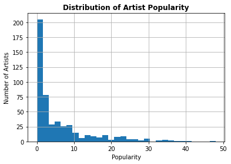

```python
# Creating plot
ax = artist_df.hist(column='Popularity', bins=30)

for x in ax[0]:
  x.set_title('Distribution of Artist Popularity', weight='bold', size=12)
  # Set x-axis label
  x.set_xlabel('Popularity')

  # Set y-axis label
  x.set_ylabel('Number of Artists')
```

Here we have a power law distribution. And it makes sense--there are bound to be many creators for things like small cover albums and niche indie titles, and on the other hand very few well-known composers. Who are the 10 most popular?

```python
artist_df.sort_values('Popularity').tail(10)
```

|  | Artist | Popularity |
| --- | --- | --- |
| 370 | Ace of Hearts | 33.000000 |
| 224 | Lunity | 34.000000 |
| 32 | Matthewせいじ | 34.000000 |
| 66 | Jukio Kallio | 35.000000 |
| 82 | Pascal Michael Stiefel | 36.000000 |
| 287 | DM DOKURO | 36.083333 |
| 407 | Kuraine | 37.000000 |
| 377 | Christa Lee | 39.000000 |
| 222 | In Love With a Ghost | 40.000000 |
| 382 | 2 Mello | 48.000000 |

Let's do the same thing for track popularity

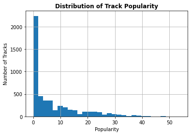

```python
# Creating plot
ax = track_df.hist(column='Popularity', bins=30)

for x in ax[0]:
  x.set_title('Distribution of Track Popularity', weight='bold', size=12)
  # Set x-axis label
  x.set_xlabel('Popularity')

  # Set y-axis label
  x.set_ylabel('Number of Tracks')
```

Now let's move onto price. Here we graph the popularity of an album versus price of the album. This was motivated by wanting to see if a high price point would deter purchases and by extent popularity, or if fans of a niche music subgroup may be willing to spend a premuim on songs from games they are more dedicated to.

```python
# determining average price
digital_prices = album_df['Digital Price'].dropna()
print('average digital price: ' + str(digital_prices.mean()))

cd_prices = album_df['CD Price'].dropna()
print('average cd price: ' + str(cd_prices.mean()))

vinyl_prices = album_df['Vinyl Price'].dropna()
print('average vinyl price: ' + str(vinyl_prices.mean()))
```

```
average digital price: 7.402508710801394
average cd price: 22.068181818181817
average vinyl price: 41.1578947368421
```

So the average  
Digital Download price is about \$7.40 <br /> CD price is about \$22.07  
Vinyl Record price is about \$41.16  
This all checks out with intuition -- physical copies of music run for higher prices, especially between CDs and vinyls

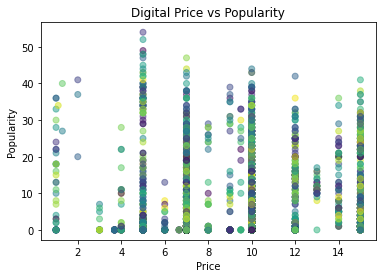

```python
# graphing digital download price over popularity
import numpy as np
album_df = pd.read_csv ('full_album_df.csv').dropna(subset=['Album ID'])
merge_df = pd.merge(track_df, album_df, on='Album ID', how='left')

prices = merge_df['Digital Price']
popularity = merge_df['Popularity']
colors = np.random.rand(5134)

plt.scatter(prices, popularity, c=colors, alpha=0.5)
plt.title("Digital Price vs Popularity")
plt.xlabel("Price")
plt.ylabel("Popularity")
plt.show()
```

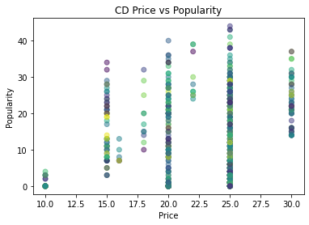

```python
prices = merge_df['CD Price']

plt.scatter(prices, popularity, c=colors, alpha=0.5)
plt.title("CD Price vs Popularity")
plt.xlabel("Price")
plt.ylabel("Popularity")
plt.show()
```

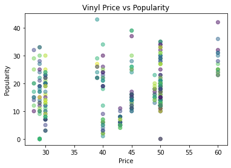

```python
prices = merge_df['Vinyl Price']

plt.scatter(prices, popularity, c=colors, alpha=0.5)
plt.title("Vinyl Price vs Popularity")
plt.xlabel("Price")
plt.ylabel("Popularity")
plt.show()
```

Surprisingly, we find that there seems to be little correlation between the price of an album. The price of an album in general does not give a good indication about how popular it will be. We will explore how different pricing can predict popularity more in the hypothesis testing section.

Now let's analyze tagging. Something we wanted to explore was finding out the most common genres in videogame music. Here we used the words and phrases albums were tagged with as a proxy for the genres/ideas in the albums. To communicate it in a visually accessible way, we decided to go with a wordcloud to get a rough estimate of how these common tags manifest in our data.

```python
import pandas as pd
import ast
import matplotlib.pyplot as plt
import matplotlib as mpl
from wordcloud import WordCloud, STOPWORDS, ImageColorGenerator
from PIL import Image

album_df = pd.read_csv ('full_album_df.csv').dropna(subset=['Album ID'])

# changes string representation of array into 2D array
tags = album_df['Tags']
tags_array = []
all_tags = []

for tag in tags:
  tags_array.append(ast.literal_eval(tag))

for array in tags_array:
  for tag in array:
    all_tags.append(tag)

len_total_tags = len(all_tags) # 3220 total tags

uniq_tags = sorted(set(all_tags))
len_uniq_tags = len(uniq_tags) # 757 unique tags
```

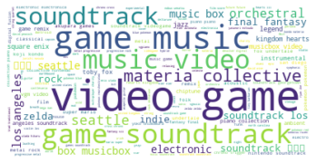

```python
# preprocessing tag data for wordcloud parameter input
text = ' '.join(all_tags).lower()
wordcloud = WordCloud(background_color='white', stopwords = STOPWORDS, collocations=True).generate(text)

# plotting wordcloud object
plt.imshow(wordcloud, interpolation='bilInear')
plt.axis('off')
plt.show()
```

This wordcloud doesn't give us much information. We know this dataset is based on videogame music, so keywords such as "video game" and "game music" become a bit redundant, and give little insight onto specific genres or popular games. To tweak this analysis, we added thesee keywords to our STOPWORDS list, which are common words that should not be included in the wordcloud.

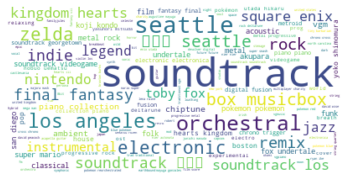

```python
# updating stopwords list
stop_words = ['game', 'games', 'music', 'video', 'materia', 'collective'] + sorted(STOPWORDS)
wordcloud2 = WordCloud(background_color='white', stopwords = stop_words, collocations=True).generate(text)

plt.imshow(wordcloud2, interpolation='bilInear')
plt.axis('off')
plt.show()
```

This wordcloud gives us a bit more information. From here, we can infer entire videogame soundtracks are commonly published by this record label, as opposed to indivually released songs. We can also begin to see some popular gaming companies start to emege in the tags, such as "nintendo," "square enix," or even independent developers such as "toby fox." Interestingly, we also see a common occurance of "▯▯▯" which may indicate tags written in other languages that cannot be displayed in the wordcloud. This gives insight on the diversity of nations popular videogame music is produced from, and whether or not their language is recognized by unicode characters. Another category of common tags seems to be, like we expected, genre, with tags like "rock," "jazz," "chiptune," "electronic," and "orchestral."

Out of curiosity, we wanted to calculate the average duration of a track.

```python
duration = track_df['Duration (ms)']
durations = []

for song in duration:
  durations.append(song)

# finding mean duration
mean_duration = sum(duration)/len(duration)

# converting milliseconds to seconds
seconds_raw = mean_duration/1000

# the average track is 177.50736005911693 seconds long
minutes_raw = seconds_raw/60

# the average track is 2.958456000985282 minutes long
# time is measured in base 60, so we multiply the remainder by 60

remaining = 0.958456000985282 * 60
print('This comes to about a 2m 58s track length average')
```

```
This comes to about a 2m 58s track length average
```

One last analysis we want to do is seeing the relationship between the number of tracks an album has, and its pricing between the digital, CD, and vinyl releases

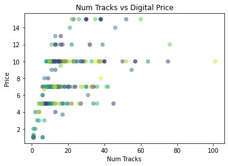

```python
# digital price
num_tracks = album_df['Number of Tracks']
digital_prices = album_df['Digital Price']
colors = np.random.rand(291)

plt.scatter(num_tracks, digital_prices, c=colors, alpha=0.5)
plt.title("Num Tracks vs Digital Price")
plt.xlabel("Num Tracks")
plt.ylabel("Price")
plt.show()
```

[figure not shown]

```python
# CD price
cd_prices = album_df['Digital Price']

plt.scatter(num_tracks, cd_prices, c=colors, alpha=0.5)
plt.title("Num Tracks vs CD Price")
plt.xlabel("Num Tracks")
plt.ylabel("Price")
plt.show()
```

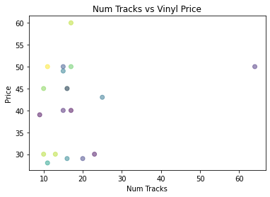

```python
# vinyl price
vinyl_prices = album_df['Vinyl Price']

plt.scatter(num_tracks, vinyl_prices, c=colors, alpha=0.5)
plt.title("Num Tracks vs Vinyl Price")
plt.xlabel("Num Tracks")
plt.ylabel("Price")
plt.show()
```

# Hypothesis Testing

Our null hypothesis is that there is a positive relationship between the number of tracks in an album and its price. Bigger albums intuitively should cost more due to production costs. We will test for this relationship for all three pricing options.  
The alternative hypothesis is that there is no relationship between the number of tracks and the album price.

```python
import matplotlib.pyplot as plt
from sklearn.linear_model import LinearRegression
```

```
coefficient of determination for Vinyl: 0.04620969656267049
coefficient of determination for CD: 0.06923866753299246
coefficient of determination for Digital: 0.2916036574717047
```

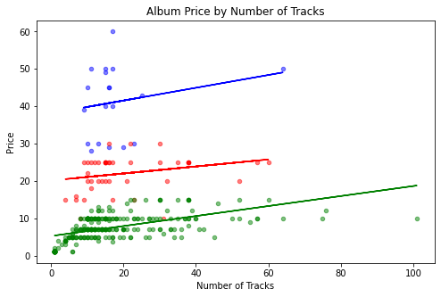

```python
fig, ax = plt.subplots(figsize=(8,5))
for (price_type, color) in zip(['Vinyl', 'CD', 'Digital'], ['blue', 'red', 'green']):
    price = price_type + ' Price'
    album_df.plot.scatter(x='Number of Tracks', y=price, c=color, alpha=0.5, ax=ax, ylabel='Price', title='Album Price by Number of Tracks')
    subdf = album_df.dropna(subset=[price])
    x = np.array(subdf['Number of Tracks']).reshape((-1, 1))
    y = np.array(subdf[price])

    model = LinearRegression().fit(x,y)
    a = model.coef_[0]
    b = model.intercept_
    ax.plot(x, (a*x)+ b, c=color, alpha=1)
    print('coefficient of determination for ' + price_type + ': ' + str(model.score(x, y)))
```

Our new null hypothesis is that there is a positive relationship between the average popularity of the songs in an album and the album price. Intuitively, more in-demand music would be priced higher. We will test for this relationship for all three pricing options. The alternative hypothesis is that there is no relationship between the average popularity of the songs in an album and the album price.

```python
# Album Popularity will be the mean of its tracks
album_df['Album Popularity'] = album_df['Album ID'].apply(lambda x: track_df[track_df['Album ID'] == x]['Popularity'].mean())
```

```
coefficient of determination for Vinyl: 0.10082127961333509
coefficient of determination for CD: 0.07243359786179127
coefficient of determination for Digital: 0.0003468393925475377
```

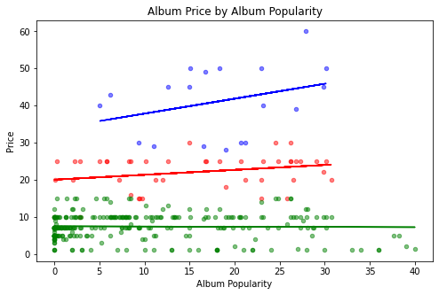

```python
fig, ax = plt.subplots(figsize=(8,5))
for (price_type, color) in zip(['Vinyl', 'CD', 'Digital'], ['blue', 'red', 'green']):
    price = price_type + ' Price'
    album_df.plot.scatter(x='Album Popularity', y=price, c=color, alpha=0.5, ax=ax, ylabel='Price', title='Album Price by Album Popularity')
    subdf = album_df.dropna(subset=[price])
    x = np.array(subdf['Album Popularity']).reshape((-1, 1))
    y = np.array(subdf[price])

    model = LinearRegression().fit(x,y)
    a = model.coef_[0]
    b = model.intercept_
    ax.plot(x, (a*x)+ b, c=color, alpha=1)
    print('coefficient of determination for ' + price_type + ': ' + str(model.score(x, y)))
```

Wow! Digital price is perceptibly even less correlated with average popularity than with album length. The other pricing options are similarly low in correlation, but not as drastically as Digital. This is corroborated with the low coefficients of determination for each of the pricing options.

# Conclusion & Additional Insights

After delving into our data, we were able to learn some pretty cool things about videogame music as a whole.

It was very surprising to have our expections for album price subverted by our linear models as what we thought the data would show seemed pretty self-explanatory. As it turns out, that trend just wasn't in the data.

In terms of our section where we analyze how album and track factors relate to popularity, it would be helpful to have data column telling us the game or franchise the album was from. While factors such as artist and price may have a strong influence on a song or album's popularity for more generalized songs, we recgonize that a driving favor for popularity regarding videogame music is, not surprisingly, the videogame itself. Aside from this, we were able to gather that artists themselves do not track much popularity. The highest artist popularity peaked at just 48, especially given the scale measures from 1-100. This can suggest that it is moreso the music and associated franchise that garner popularity through its music, and less so from any particular artist's input.